# [Python for data analysis] - Diabetes Dataset

## Introduction

This dataset represents 10 years (1999-2008) of clinical care at 130 US hospitals and integrated delivery networks. It includes over 50 features representing patient and hospital outcomes. Information was extracted from the database for encounters that satisfied the following criteria.

- (1) It is an inpatient encounter (a hospital admission).
- (2) It is a diabetic encounter, that is, one during which any kind of diabetes was entered to the system as a diagnosis.
- (3) The length of stay was at least 1 day and at most 14 days.
- (4) Laboratory tests were performed during the encounter.
- (5) Medications were administered during the encounter.

The data contains such attributes as patient number, race, gender, age, admission type, time in hospital, medical specialty of admitting physician, number of lab test performed, HbA1c test result, diagnosis, number of medication, diabetic medications, number of outpatient, inpatient, and emergency visits in the year before the hospitalization, etc.

Dataset can be found at https://archive.ics.uci.edu/ml/datasets/diabetes+130-us+hospitals+for+years+1999-2008

## Table Of Contents

- Introduction
- Table Of Contents
- Data Exploration
  - Dataset
  - Overview
  - Columns signification
  - Profiling report
  - Data cleaning
  - Rethink columns
- Data Visualization
  - Correlation Matrix
  - Distributions
  - Deeper analysis
- Principal Component Analysis
- Machine Learning
  - Case 1 : Predict patient's readmission under 30 days
    - Preparing data
      - Building of the Machine Learning oriented dataset
      - Dealing with the column to predict (Predict patient's readmission under 30 days)
      - Dealing with categorical features
      - Shuffling
      - Splitting
      - Scaling
    - Fitting models
      - Model 1: K-Nearest Neighbors (KNN)
      - Model 2: Logistic regression
      - Model 3: Linear SVC
      - Model 4: Random Forest
      - Model 5: Adaptive boosting
      - Model 6: Decision Tree
      - Model 7: ExtraTrees
      - Model 8: Naive Bayes Classifier
    - Tuning models
    - Comparing models
      - Performance
      - Barplot
  - Case 2 : Predict patient's readmission below and above 30 days
    - Dealing with the column to predict (Predict patient's readmission below AND above 30 days)
      - Model 1 : K-Nearest Neighbors (KNN) version 2
      - Model 2 : Logistic Regression version 2
      - Model 3 : Linear SVC
      - Model 4 : Random Forest
      - Model 5 : Adaptive boosting
      - Model 6 : Decision Tree
      - Model 7 : ExtraTrees
      - Model 8 : Naive Bayes Classifier
    - Tuning models
    - Comparing all models
      - Performance
      - Barplot
- Conclusion
  - Remarks about cases

## Data Exploration

### Importation of all the librairies that we will use

```python
import pandas as pd
import numpy as np
import matplotlib.pyplot as plt
import seaborn as sns
import random
from bokeh.plotting import figure, output_file, show
from bokeh.io import output_notebook, show
from bokeh.layouts import gridplot
import pandas_bokeh
from pandas_profiling import ProfileReport
from tabulate import tabulate
```

### Display settings

We set the bokeh output to notebook

```python
output_notebook()
```

We define a permanent style for the plot in order to have an homogenous vizualisation

```python
plt.style.use('default')
from bokeh.io import curdoc
curdoc().theme = 'dark_minimal'
```

All bokeh graphs are dynamic, you can also move the mouse over an element to see which data he refers to.  
You can also interact with the legend of the plot to show/hide some categories

```python
%matplotlib inline
```

We set the maximum number of columns allowed to be displayed to 100 so that the all dataframe can be printed

```python
pd.set_option('display.max_columns', 100)
```

### Importation of the dataset

We create a dataframe by reading a csv file and importing the data

```python
diabetes_df = pd.read_csv(r'../Dataset/diabetic_data.csv', sep =',', na_values="?", low_memory = False)
diabetes_df.head()
```

|  | encounter_id | patient_nbr | race | gender | age | weight | admission_type_id | discharge_disposition_id | admission_source_id | time_in_hospital | payer_code | medical_specialty | num_lab_procedures | num_procedures | num_medications | number_outpatient | number_emergency | number_inpatient | diag_1 | diag_2 | diag_3 | number_diagnoses | max_glu_serum | A1Cresult | metformin | repaglinide | nateglinide | chlorpropamide | glimepiride | … |
| --- | --- | --- | --- | --- | --- | --- | --- | --- | --- | --- | --- | --- | --- | --- | --- | --- | --- | --- | --- | --- | --- | --- | --- | --- | --- | --- | --- | --- | --- | --- |
| 0 | 2278392 | 8222157 | Caucasian | Female | [0-10) | NaN | 6 | 25 | 1 | 1 | NaN | Pediatrics-Endocrinology | 41 | 0 | 1 | 0 | 0 | 0 | 250.83 | NaN | NaN | 1 | None | None | No | No | No | No | No | … |
| 1 | 149190 | 55629189 | Caucasian | Female | [10-20) | NaN | 1 | 1 | 7 | 3 | NaN | NaN | 59 | 0 | 18 | 0 | 0 | 0 | 276 | 250.01 | 255 | 9 | None | None | No | No | No | No | No | … |
| 2 | 64410 | 86047875 | AfricanAmerican | Female | [20-30) | NaN | 1 | 1 | 7 | 2 | NaN | NaN | 11 | 5 | 13 | 2 | 0 | 1 | 648 | 250 | V27 | 6 | None | None | No | No | No | No | No | … |
| 3 | 500364 | 82442376 | Caucasian | Male | [30-40) | NaN | 1 | 1 | 7 | 2 | NaN | NaN | 44 | 1 | 16 | 0 | 0 | 0 | 8 | 250.43 | 403 | 7 | None | None | No | No | No | No | No | … |
| 4 | 16680 | 42519267 | Caucasian | Male | [40-50) | NaN | 1 | 1 | 7 | 1 | NaN | NaN | 51 | 0 | 8 | 0 | 0 | 0 | 197 | 157 | 250 | 5 | None | None | No | No | No | No | No | … |

```python
diabetes_df.tail()
```

|  | encounter_id | patient_nbr | race | gender | age | weight | admission_type_id | discharge_disposition_id | admission_source_id | time_in_hospital | payer_code | medical_specialty | num_lab_procedures | num_procedures | num_medications | number_outpatient | number_emergency | number_inpatient | diag_1 | diag_2 | diag_3 | number_diagnoses | max_glu_serum | A1Cresult | metformin | repaglinide | nateglinide | chlorpropamide | glimepiride | … |
| --- | --- | --- | --- | --- | --- | --- | --- | --- | --- | --- | --- | --- | --- | --- | --- | --- | --- | --- | --- | --- | --- | --- | --- | --- | --- | --- | --- | --- | --- | --- |
| 101761 | 443847548 | 100162476 | AfricanAmerican | Male | [70-80) | NaN | 1 | 3 | 7 | 3 | MC | NaN | 51 | 0 | 16 | 0 | 0 | 0 | 250.13 | 291 | 458 | 9 | None | >8 | Steady | No | No | No | No | … |
| 101762 | 443847782 | 74694222 | AfricanAmerican | Female | [80-90) | NaN | 1 | 4 | 5 | 5 | MC | NaN | 33 | 3 | 18 | 0 | 0 | 1 | 560 | 276 | 787 | 9 | None | None | No | No | No | No | No | … |
| 101763 | 443854148 | 41088789 | Caucasian | Male | [70-80) | NaN | 1 | 1 | 7 | 1 | MC | NaN | 53 | 0 | 9 | 1 | 0 | 0 | 38 | 590 | 296 | 13 | None | None | Steady | No | No | No | No | … |
| 101764 | 443857166 | 31693671 | Caucasian | Female | [80-90) | NaN | 2 | 3 | 7 | 10 | MC | Surgery-General | 45 | 2 | 21 | 0 | 0 | 1 | 996 | 285 | 998 | 9 | None | None | No | No | No | No | No | … |
| 101765 | 443867222 | 175429310 | Caucasian | Male | [70-80) | NaN | 1 | 1 | 7 | 6 | NaN | NaN | 13 | 3 | 3 | 0 | 0 | 0 | 530 | 530 | 787 | 9 | None | None | No | No | No | No | No | … |

By fisrt obersving the data, we can see that there are a lot of values in this dataset. There are **101 766 row** and **50 columns**. We will certainly have to **analyze** and **clean up** these data a little to reduce them and make them more treatable.

### First overview

Let's use the info() method in order to observe the structure and the type of the dataframe

```python
 diabetes_df.info()
```

```
<class 'pandas.core.frame.DataFrame'>
RangeIndex: 101766 entries, 0 to 101765
Data columns (total 50 columns):
 #   Column                    Non-Null Count   Dtype
---  ------                    --------------   -----
 0   encounter_id              101766 non-null  int64
 1   patient_nbr               101766 non-null  int64
 2   race                      99493 non-null   object
 3   gender                    101766 non-null  object
 4   age                       101766 non-null  object
 5   weight                    3197 non-null    object
 6   admission_type_id         101766 non-null  int64
 7   discharge_disposition_id  101766 non-null  int64
 8   admission_source_id       101766 non-null  int64
 9   time_in_hospital          101766 non-null  int64
```

[output cut: 42 more lines]

```python
diabetes_df.describe().apply(lambda s: s.apply('{0:.2f}'.format))
```

|  | encounter_id | patient_nbr | admission_type_id | discharge_disposition_id | admission_source_id | time_in_hospital | num_lab_procedures | num_procedures | num_medications | number_outpatient | number_emergency | number_inpatient | number_diagnoses |
| --- | --- | --- | --- | --- | --- | --- | --- | --- | --- | --- | --- | --- | --- |
| count | 101766.00 | 101766.00 | 101766.00 | 101766.00 | 101766.00 | 101766.00 | 101766.00 | 101766.00 | 101766.00 | 101766.00 | 101766.00 | 101766.00 | 101766.00 |
| mean | 165201645.62 | 54330400.69 | 2.02 | 3.72 | 5.75 | 4.40 | 43.10 | 1.34 | 16.02 | 0.37 | 0.20 | 0.64 | 7.42 |
| std | 102640295.98 | 38696359.35 | 1.45 | 5.28 | 4.06 | 2.99 | 19.67 | 1.71 | 8.13 | 1.27 | 0.93 | 1.26 | 1.93 |
| min | 12522.00 | 135.00 | 1.00 | 1.00 | 1.00 | 1.00 | 1.00 | 0.00 | 1.00 | 0.00 | 0.00 | 0.00 | 1.00 |
| 25% | 84961194.00 | 23413221.00 | 1.00 | 1.00 | 1.00 | 2.00 | 31.00 | 0.00 | 10.00 | 0.00 | 0.00 | 0.00 | 6.00 |
| 50% | 152388987.00 | 45505143.00 | 1.00 | 1.00 | 7.00 | 4.00 | 44.00 | 1.00 | 15.00 | 0.00 | 0.00 | 0.00 | 8.00 |
| 75% | 230270887.50 | 87545949.75 | 3.00 | 4.00 | 7.00 | 6.00 | 57.00 | 2.00 | 20.00 | 0.00 | 0.00 | 1.00 | 9.00 |
| max | 443867222.00 | 189502619.00 | 8.00 | 28.00 | 25.00 | 14.00 | 132.00 | 6.00 | 81.00 | 42.00 | 76.00 | 21.00 | 16.00 |

### Columns signification

Now we want to know and understand the signification of the differents columns in order to analyse them. With this dataset, we have a pdf document explaining some characteristics of these data:

Here, we will use the pandas_profiling library to call the profil_report() function. This library extends the DataFrame for a quick analysis

This report contains several informations such as the types of columns in the dataframe, the uniques and missing values, it will do some quantile and descriptive statistics, will search some correlations between the differents features. We will use it as a base to clean up our data.

### Profile report

```python
#report = ProfileReport(diabetes_df, title = "Diabetes dataset overview", dark_mode = True)
#report
```

### Data cleaning

#### Counting unknown values

Here we count the pourcentage of missing value in the differents columns of this dataframe

```python
missing_values = diabetes_df.isna().sum() / len(diabetes_df) * 100
missing_values = missing_values[missing_values > 0]
missing_values.sort_values(inplace=True)
missing_values = missing_values.to_frame()
missing_values
```

|  | 0 |
| --- | --- |
| diag_1 | 0.020636 |
| diag_2 | 0.351787 |
| diag_3 | 1.398306 |
| race | 2.233555 |
| payer_code | 39.557416 |
| medical_specialty | 49.082208 |
| weight | 96.858479 |

#### Dropping columns with too much missing values

With the precedent results, we eliminate the columns that have too many missing values

```python
diabetes_df.drop(columns = ['weight', 'medical_specialty', 'payer_code', 'encounter_id'], inplace = True)
```

Some columns provide a constant value for every row, it is useless so we can eliminate them too.

```python
diabetes_df.drop(columns = ['examide', 'citoglipton', 'glimepiride-pioglitazone', 'metformin-rosiglitazone', 'metformin-pioglitazone'], inplace = True)
```

#### Dropping redundant rows

When we analysed some data in this dataset, we observed that there was some redundant rows, some rows had the same number of patient value, and sometimes the linked variables were not coherent

We also drop these rows

```python
diabetes_df.drop_duplicates(subset = "patient_nbr", keep = 'first', inplace = True)
```

Because of the deletion of redundant rows, some index were erased, we need to reset index

```python
diabetes_df.reset_index(inplace = True, drop = True)
diabetes_df
```

|  | patient_nbr | race | gender | age | admission_type_id | discharge_disposition_id | admission_source_id | time_in_hospital | num_lab_procedures | num_procedures | num_medications | number_outpatient | number_emergency | number_inpatient | diag_1 | diag_2 | diag_3 | number_diagnoses | max_glu_serum | A1Cresult | metformin | repaglinide | nateglinide | chlorpropamide | glimepiride | acetohexamide | glipizide | glyburide | tolbutamide | … |
| --- | --- | --- | --- | --- | --- | --- | --- | --- | --- | --- | --- | --- | --- | --- | --- | --- | --- | --- | --- | --- | --- | --- | --- | --- | --- | --- | --- | --- | --- | --- |
| 0 | 8222157 | Caucasian | Female | [0-10) | 6 | 25 | 1 | 1 | 41 | 0 | 1 | 0 | 0 | 0 | 250.83 | NaN | NaN | 1 | None | None | No | No | No | No | No | No | No | No | No | … |
| 1 | 55629189 | Caucasian | Female | [10-20) | 1 | 1 | 7 | 3 | 59 | 0 | 18 | 0 | 0 | 0 | 276 | 250.01 | 255 | 9 | None | None | No | No | No | No | No | No | No | No | No | … |
| 2 | 86047875 | AfricanAmerican | Female | [20-30) | 1 | 1 | 7 | 2 | 11 | 5 | 13 | 2 | 0 | 1 | 648 | 250 | V27 | 6 | None | None | No | No | No | No | No | No | Steady | No | No | … |
| 3 | 82442376 | Caucasian | Male | [30-40) | 1 | 1 | 7 | 2 | 44 | 1 | 16 | 0 | 0 | 0 | 8 | 250.43 | 403 | 7 | None | None | No | No | No | No | No | No | No | No | No | … |
| 4 | 42519267 | Caucasian | Male | [40-50) | 1 | 1 | 7 | 1 | 51 | 0 | 8 | 0 | 0 | 0 | 197 | 157 | 250 | 5 | None | None | No | No | No | No | No | No | Steady | No | No | … |
| ... | ... | ... | ... | ... | ... | ... | ... | ... | ... | ... | ... | ... | ... | ... | ... | ... | ... | ... | ... | ... | ... | ... | ... | ... | ... | ... | ... | ... | ... | … |
| 71513 | 183087545 | Caucasian | Female | [70-80) | 1 | 1 | 7 | 9 | 50 | 2 | 33 | 0 | 0 | 0 | 574 | 574 | 250.02 | 9 | None | >7 | No | No | No | No | No | No | No | Up | No | … |
| 71514 | 188574944 | Other | Female | [40-50) | 1 | 1 | 7 | 14 | 73 | 6 | 26 | 0 | 1 | 0 | 592 | 599 | 518 | 9 | None | >8 | No | No | No | No | No | No | Steady | No | No | … |
| 71515 | 140199494 | Other | Female | [60-70) | 1 | 1 | 7 | 2 | 46 | 6 | 17 | 1 | 1 | 1 | 996 | 585 | 403 | 9 | None | None | No | No | No | No | No | No | No | No | No | … |
| 71516 | 120975314 | Caucasian | Female | [80-90) | 1 | 1 | 7 | 5 | 76 | 1 | 22 | 0 | 1 | 0 | 292 | 8 | 304 | 9 | None | None | No | No | No | No | No | No | No | No | No | … |
| 71517 | 175429310 | Caucasian | Male | [70-80) | 1 | 1 | 7 | 6 | 13 | 3 | 3 | 0 | 0 | 0 | 530 | 530 | 787 | 9 | None | None | No | No | No | No | No | No | No | No | No | … |

71518 rows × 41 columns

### Rethink some colums format

#### Diag_1, Diag_2, Diag_3: mapping ICD9 codes with corresponding names

https://www.hindawi.com/journals/bmri/2014/781670/tab2/

We create a dictionnary in order to map the value later, this dictionnary correspond to the values found in the link above

```python
map_diag_123 = {'Circulatory' : [x for x in range(390,460)]+[785],
                'Respiratory' : [x for x in range(460,519)]+[786],
                'Digestive' : [x for x in range(520,580)]+[787],
                'Diabetes' : list(set(np.linspace(250, 251, 101)) - set([251])),
                'Injury' : [x for x in range(800,1000)],
                'Musculoskeletal' : [x for x in range(710,440)],
                'Genitourinary' : [x for x in range(580,630)]+[788],
                'Neoplasms' : list(set([x for x in range(1,280)] + [780, 781, 782, 784] + [x for x in range(790, 799)] + [x for x in range(680, 709)] + [x for x in range(290, 320)]) - set([250]))}
```

This mapping method replace all the value by their corresponding in order to have traitable data. The numeric values in the column diag1, diag2, diag3 were too scattered, we had to regroup them by using the informations in the link above

```python
def mapping_df(diabetes_df, column):
    #for the missing value
    if diabetes_df[column] is np.NaN :
        return "No data"
    value = str(diabetes_df[column])
    #there are some value that begin with a character so we treat them first to avoid errors
    if value[0] == "E" :
        return "Other"
    elif value[0] == "V" :
        return "Other"
    #we convert the others value to float to have a correct conversion
    else : value = float(diabetes_df[column])

    #now each float value is analysed and in fonction of her category, a string value will be assigned to her
    if value in [x for x in range(390,460)]+[785] : return "Circulatory"
    elif value in [x for x in range(460,519)]+[786] : return "Respiratory"
    elif value in [x for x in range(520,580)]+[787] : return "Digestive"
    elif value in list(set(np.linspace(250, 251, 101)) - set([251])) : return "Diabetes"
    elif value in [x for x in range(800,1000)] : return "Injury"
    elif value in [x for x in range(710,740)] : return "Musculoskeletal"
    elif value in [x for x in range(580,630)]+[788] : return "Genitourinary"
    elif value in list(set([x for x in range(1,280)] + [780, 781, 782, 784] + [x for x in range(790, 799)] + [x for x in range(680, 709)] + [x for x in range(290, 320)]) - set([250])) : return "Neoplasms"
    else : return "Other"
```

Now we apply the mapping method to the three differents columns

```python
diabetes_df['diag_1'] = diabetes_df.apply(mapping_df, axis = 1, column = 'diag_1')
diabetes_df['diag_2'] = diabetes_df.apply(mapping_df, axis = 1, column = 'diag_2')
diabetes_df['diag_3'] = diabetes_df.apply(mapping_df, axis = 1, column = 'diag_3')
```

Now we want to create new columns to interpret the differents diagnosis of the patient, to do so, we first create a method that will give boolean value for the existence of the different diagnosis

```python
def value_exists(column1, column2, column3, diagnosis):
    value = []
    for i in range(len(column1)):
        if str(column1[i]) == diagnosis or str(column2[i]) == diagnosis or str(column3[i]) == diagnosis:
            #if the correspondant diagnosis is present
            value.append(True)
        else : value.append(False)
    return value
```

Now we map this value into new columns to interpret later with graphs and learning models

```python
for diag in map_diag_123.keys():
    name = "Diag_" + str(diag)
    diabetes_df[name] = pd.Series(value_exists(diabetes_df['diag_1'],
                                               diabetes_df['diag_2'],
                                               diabetes_df['diag_3'], diag))
```

### Rethink some other columns

We want to see what are the actual differents names of the columns of this dataset

```python
diabetes_df.columns
```

```
Index(['patient_nbr', 'race', 'gender', 'age', 'admission_type_id',
       'discharge_disposition_id', 'admission_source_id', 'time_in_hospital',
       'num_lab_procedures', 'num_procedures', 'num_medications',
       'number_outpatient', 'number_emergency', 'number_inpatient', 'diag_1',
       'diag_2', 'diag_3', 'number_diagnoses', 'max_glu_serum', 'A1Cresult',
       'metformin', 'repaglinide', 'nateglinide', 'chlorpropamide',
       'glimepiride', 'acetohexamide', 'glipizide', 'glyburide', 'tolbutamide',
       'pioglitazone', 'rosiglitazone', 'acarbose', 'miglitol', 'troglitazone',
       'tolazamide', 'insulin', 'glyburide-metformin', 'glipizide-metformin',
       'change', 'diabetesMed', 'readmitted', 'Diag_Circulatory',
       'Diag_Respiratory', 'Diag_Digestive', 'Diag_Diabetes', 'Diag_Injury',
       'Diag_Musculoskeletal', 'Diag_Genitourinary', 'Diag_Neoplasms'],
      dtype='object')
```

We can map another columns to have a better idea of the different admission type in the later graphs. We use here the mapping values gave in a document with the dataset

```python
map_admission_type_id = {1: 'Emergency',
                         2:'Urgent',
                         3:'Elective',
                         4:'Newborn',
                         5:'Not Available',
                         6:'NULL',
                         7:'Trauma Center',
                         8 :'Not Mapped'}

diabetes_df.admission_type_id = diabetes_df.admission_type_id.map(map_admission_type_id)
```

```python
map_discharge_disposition_id = {1:"Discharged to home",
                                2:"Discharged/transferred to another short term hospital",
                                3:"Discharged/transferred to SNF",
                                4:"Discharged/transferred to ICF",
                                5:"Discharged/transferred to another type of inpatient care institution",
                                6:"Discharged/transferred to home with home health service",
                                7:"Left AMA",
                                8:"Discharged/transferred to home under care of Home IV provider",
                                9:"Admitted as an inpatient to this hospital",
                                10:"Neonate discharged to another hospital for neonatal aftercare",
                                11:"Expired",
                                12:"Still patient or expected to return for outpatient services",
                                13:"Hospice / home",
                                14:"Hospice / medical facility",
                                15:"Discharged/transferred within this institution to Medicare approved swing bed",
                                16:"Discharged/transferred/referred another institution for outpatient services",
                                17:"Discharged/transferred/referred to this institution for outpatient services",
                                18:"NULL",
                                19:"Expired at home. Medicaid only, hospice.",
                                20:"Expired in a medical facility. Medicaid only, hospice.",
                                21:"Expired, place unknown. Medicaid only, hospice.",
                                22:"Discharged/transferred to another rehab fac including rehab units of a hospital .",
                                23:"Discharged/transferred to a long term care hospital.",
                                24:"Discharged/transferred to a nursing facility certified under Medicaid but not certified under Medicare.",
                                25:"Not Mapped",
                                26:"Unknown/Invalid",
                                30:"Discharged/transferred to another Type of Health Care Institution not Defined Elsewhere",
                                27:"Discharged/transferred to a federal health care facility.",
                                28:"Discharged/transferred/referred to a psychiatric hospital of psychiatric distinct part unit of a hospital",
                                29:"Discharged/transferred to a Critical Access Hospital (CAH)."}

diabetes_df.discharge_disposition_id = diabetes_df.discharge_disposition_id.map(map_discharge_disposition_id)
```

```python
map_admission_source_id = {1:"Physician Referral",
                           2:"Clinic Referral",
                           3:"HMO Referral",
                           4:"Transfer from a hospital",
                           5:"Transfer from a Skilled Nursing Facility (SNF)",
                           6:"Transfer from another health care facility",
                           7:"Emergency Room",
                           8:"Court/Law Enforcement",
                           9:"Not Available",
                           10:"Transfer from critial access hospital",
                           11:"Normal Delivery",
                           12:"Premature Delivery",
                           13:"Sick Baby",
                           14:"Extramural Birth",
                           15:"Not Available",
                           17:"NULL",
                           18:"Transfer From Another Home Health Agency",
                           19:"Readmission to Same Home Health Agency",
                           20:"Not Mapped",
                           21:"Unknown/Invalid",
                           22:"Transfer from hospital inpt/same fac reslt in a sep claim",
                           23:"Born inside this hospital",
                           24:"Born outside this hospital",
                           25:"Transfer from Ambulatory Surgery Center",
                           26:"Transfer from Hospice"}

diabetes_df.admission_source_id = diabetes_df.admission_source_id.map(map_admission_source_id)
```

```python
diabetes_df
```

|  | patient_nbr | race | gender | age | admission_type_id | discharge_disposition_id | admission_source_id | time_in_hospital | num_lab_procedures | num_procedures | num_medications | number_outpatient | number_emergency | number_inpatient | diag_1 | diag_2 | diag_3 | number_diagnoses | max_glu_serum | A1Cresult | metformin | repaglinide | nateglinide | chlorpropamide | glimepiride | acetohexamide | glipizide | glyburide | tolbutamide | … |
| --- | --- | --- | --- | --- | --- | --- | --- | --- | --- | --- | --- | --- | --- | --- | --- | --- | --- | --- | --- | --- | --- | --- | --- | --- | --- | --- | --- | --- | --- | --- |
| 0 | 8222157 | Caucasian | Female | [0-10) | NULL | Not Mapped | Physician Referral | 1 | 41 | 0 | 1 | 0 | 0 | 0 | Diabetes | No data | No data | 1 | None | None | No | No | No | No | No | No | No | No | No | … |
| 1 | 55629189 | Caucasian | Female | [10-20) | Emergency | Discharged to home | Emergency Room | 3 | 59 | 0 | 18 | 0 | 0 | 0 | Neoplasms | Diabetes | Neoplasms | 9 | None | None | No | No | No | No | No | No | No | No | No | … |
| 2 | 86047875 | AfricanAmerican | Female | [20-30) | Emergency | Discharged to home | Emergency Room | 2 | 11 | 5 | 13 | 2 | 0 | 1 | Other | Diabetes | Other | 6 | None | None | No | No | No | No | No | No | Steady | No | No | … |
| 3 | 82442376 | Caucasian | Male | [30-40) | Emergency | Discharged to home | Emergency Room | 2 | 44 | 1 | 16 | 0 | 0 | 0 | Neoplasms | Diabetes | Circulatory | 7 | None | None | No | No | No | No | No | No | No | No | No | … |
| 4 | 42519267 | Caucasian | Male | [40-50) | Emergency | Discharged to home | Emergency Room | 1 | 51 | 0 | 8 | 0 | 0 | 0 | Neoplasms | Neoplasms | Diabetes | 5 | None | None | No | No | No | No | No | No | Steady | No | No | … |
| ... | ... | ... | ... | ... | ... | ... | ... | ... | ... | ... | ... | ... | ... | ... | ... | ... | ... | ... | ... | ... | ... | ... | ... | ... | ... | ... | ... | ... | ... | … |
| 71513 | 183087545 | Caucasian | Female | [70-80) | Emergency | Discharged to home | Emergency Room | 9 | 50 | 2 | 33 | 0 | 0 | 0 | Digestive | Digestive | Diabetes | 9 | None | >7 | No | No | No | No | No | No | No | Up | No | … |
| 71514 | 188574944 | Other | Female | [40-50) | Emergency | Discharged to home | Emergency Room | 14 | 73 | 6 | 26 | 0 | 1 | 0 | Genitourinary | Genitourinary | Respiratory | 9 | None | >8 | No | No | No | No | No | No | Steady | No | No | … |
| 71515 | 140199494 | Other | Female | [60-70) | Emergency | Discharged to home | Emergency Room | 2 | 46 | 6 | 17 | 1 | 1 | 1 | Injury | Genitourinary | Circulatory | 9 | None | None | No | No | No | No | No | No | No | No | No | … |
| 71516 | 120975314 | Caucasian | Female | [80-90) | Emergency | Discharged to home | Emergency Room | 5 | 76 | 1 | 22 | 0 | 1 | 0 | Neoplasms | Neoplasms | Neoplasms | 9 | None | None | No | No | No | No | No | No | No | No | No | … |
| 71517 | 175429310 | Caucasian | Male | [70-80) | Emergency | Discharged to home | Emergency Room | 6 | 13 | 3 | 3 | 0 | 0 | 0 | Digestive | Digestive | Digestive | 9 | None | None | No | No | No | No | No | No | No | No | No | … |

71518 rows × 49 columns

## Data Visualization

### Correlation Matrix

A correlation matrix is used to **assess dependency** between several variables at the sasme time. The result is a table containing the correlation coefficients between each variable and the other.

The closer the coefficient (between 0 and 1) is to 1, the **more correlated** are the two associated variables.

```python
corr = diabetes_df.corr()
corr.style.background_gradient(cmap='coolwarm').set_precision(2)
```

|  | patient_nbr | time_in_hospital | num_lab_procedures | num_procedures | num_medications | number_outpatient | number_emergency | number_inpatient | number_diagnoses | Diag_Circulatory | Diag_Respiratory | Diag_Digestive | Diag_Diabetes | Diag_Injury | Diag_Musculoskeletal | Diag_Genitourinary | Diag_Neoplasms |
| --- | --- | --- | --- | --- | --- | --- | --- | --- | --- | --- | --- | --- | --- | --- | --- | --- | --- |
| patient_nbr | 1.00 | -0.02 | 0.01 | -0.02 | 0.02 | 0.09 | 0.06 | 0.09 | 0.23 | -0.02 | 0.01 | 0.01 | -0.10 | 0.02 | 0.00 | 0.05 | 0.02 |
| time_in_hospital | -0.02 | 1.00 | 0.33 | 0.19 | 0.47 | -0.01 | -0.01 | 0.06 | 0.23 | -0.03 | 0.02 | 0.01 | -0.14 | 0.05 | -0.02 | 0.05 | 0.05 |
| num_lab_procedures | 0.01 | 0.33 | 1.00 | 0.05 | 0.26 | -0.01 | 0.01 | 0.08 | 0.16 | -0.01 | 0.05 | 0.03 | -0.07 | -0.03 | -0.12 | 0.10 | 0.04 |
| num_procedures | -0.02 | 0.19 | 0.05 | 1.00 | 0.40 | -0.02 | -0.04 | -0.02 | 0.09 | 0.15 | -0.12 | 0.00 | -0.10 | 0.08 | 0.02 | -0.05 | -0.16 |
| num_medications | 0.02 | 0.47 | 0.26 | 0.40 | 1.00 | 0.03 | 0.00 | 0.04 | 0.26 | 0.09 | 0.05 | -0.05 | -0.14 | 0.09 | 0.09 | 0.01 | -0.11 |
| number_outpatient | 0.09 | -0.01 | -0.01 | -0.02 | 0.03 | 1.00 | 0.10 | 0.07 | 0.08 | -0.00 | -0.01 | -0.00 | -0.03 | -0.01 | 0.01 | 0.02 | 0.01 |
| number_emergency | 0.06 | -0.01 | 0.01 | -0.04 | 0.00 | 0.10 | 1.00 | 0.15 | 0.05 | -0.03 | 0.01 | 0.01 | 0.01 | -0.01 | -0.00 | 0.01 | 0.03 |
| number_inpatient | 0.09 | 0.06 | 0.08 | -0.02 | 0.04 | 0.07 | 0.15 | 1.00 | 0.07 | 0.01 | 0.00 | -0.00 | -0.03 | 0.01 | -0.02 | 0.01 | 0.00 |
| number_diagnoses | 0.23 | 0.23 | 0.16 | 0.09 | 0.26 | 0.08 | 0.05 | 0.07 | 1.00 | 0.06 | 0.09 | 0.01 | -0.42 | 0.07 | -0.07 | 0.14 | 0.02 |
| Diag_Circulatory | -0.02 | -0.03 | -0.01 | 0.15 | 0.09 | -0.00 | -0.03 | 0.01 | 0.06 | 1.00 | -0.04 | -0.19 | -0.14 | -0.12 | -0.10 | -0.13 | -0.33 |
| Diag_Respiratory | 0.01 | 0.02 | 0.05 | -0.12 | 0.05 | -0.01 | 0.01 | 0.00 | 0.09 | -0.04 | 1.00 | -0.10 | -0.12 | -0.10 | -0.09 | -0.10 | -0.12 |
| Diag_Digestive | 0.01 | 0.01 | 0.03 | 0.00 | -0.05 | -0.00 | 0.01 | -0.00 | 0.01 | -0.19 | -0.10 | 1.00 | -0.05 | -0.07 | -0.08 | -0.05 | -0.04 |
| Diag_Diabetes | -0.10 | -0.14 | -0.07 | -0.10 | -0.14 | -0.03 | 0.01 | -0.03 | -0.42 | -0.14 | -0.12 | -0.05 | 1.00 | -0.11 | 0.04 | -0.13 | -0.04 |
| Diag_Injury | 0.02 | 0.05 | -0.03 | 0.08 | 0.09 | -0.01 | -0.01 | 0.01 | 0.07 | -0.12 | -0.10 | -0.07 | -0.11 | 1.00 | -0.02 | -0.03 | -0.07 |
| Diag_Musculoskeletal | 0.00 | -0.02 | -0.12 | 0.02 | 0.09 | 0.01 | -0.00 | -0.02 | -0.07 | -0.10 | -0.09 | -0.08 | 0.04 | -0.02 | 1.00 | -0.06 | -0.09 |
| Diag_Genitourinary | 0.05 | 0.05 | 0.10 | -0.05 | 0.01 | 0.02 | 0.01 | 0.01 | 0.14 | -0.13 | -0.10 | -0.05 | -0.13 | -0.03 | -0.06 | 1.00 | 0.01 |
| Diag_Neoplasms | 0.02 | 0.05 | 0.04 | -0.16 | -0.11 | 0.01 | 0.03 | 0.00 | 0.02 | -0.33 | -0.12 | -0.04 | -0.04 | -0.07 | -0.09 | 0.01 | 1.00 |

Now we will use another library (seaborn) in order to plot the correlation matrix with another visual

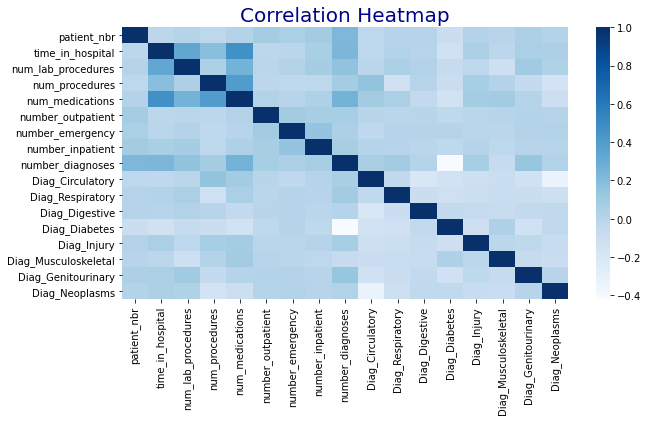

```python
#another style of correlation matrix with seaborn library
plt.figure(figsize=(10, 5))
corrM = sns.heatmap(diabetes_df.corr(), cmap = 'Blues')
corrM.set_title('Correlation Heatmap', fontdict={'fontsize':20}, color = 'darkblue' );
```

By interpreting these correlations matrix, we can observe that this dataset does not present many correlations between its different variables. The coefficients are relatively **low** and the highest ones remain **small coefficients**.

> The variables who seem to have a high correlation are :
> - **num_lab_procedures**, **num_procedures** and **num_medications** with **time_in_hospital**
> - **num_medications** with **num_lab_procedures**
> - **num_medications** with **num_procedures**
> - **number_diagnoses** with **time_in_hospital** and **num_lab_procedures** and **Diag_Diabetes**
> - **Diag_Neoplams** with **Diag_Circulatory**
> - **Diag_Digestive** with **Diag_Circulatory**

```python
diabetes_df.columns.values
```

```
array(['patient_nbr', 'race', 'gender', 'age', 'admission_type_id',
       'discharge_disposition_id', 'admission_source_id',
       'time_in_hospital', 'num_lab_procedures', 'num_procedures',
       'num_medications', 'number_outpatient', 'number_emergency',
       'number_inpatient', 'diag_1', 'diag_2', 'diag_3',
       'number_diagnoses', 'max_glu_serum', 'A1Cresult', 'metformin',
       'repaglinide', 'nateglinide', 'chlorpropamide', 'glimepiride',
       'acetohexamide', 'glipizide', 'glyburide', 'tolbutamide',
       'pioglitazone', 'rosiglitazone', 'acarbose', 'miglitol',
       'troglitazone', 'tolazamide', 'insulin', 'glyburide-metformin',
       'glipizide-metformin', 'change', 'diabetesMed', 'readmitted',
       'Diag_Circulatory', 'Diag_Respiratory', 'Diag_Digestive',
       'Diag_Diabetes', 'Diag_Injury', 'Diag_Musculoskeletal',
       'Diag_Genitourinary', 'Diag_Neoplasms'], dtype=object)
```

### Distributions

Now, using the bokeh library, we can plot some graphs, that will be more interesting with the preprocessing above  
Each feature will first be analysed individually

*Let's put some colors on that notebook* : )

```python
colors = ['dodgerblue', 'green', 'yellow', 'white', 'crimson']
```

We create a list of all columns that we want to visualize

```python
columns = diabetes_df.columns.values.tolist()
columns.remove('patient_nbr') # No need to plot an unique identifier
```

```python
plots = [] # list that will contain each bar plot
i = 0

for column in columns:
    p = diabetes_df[column].value_counts(normalize = True).sort_values(ascending=False)[0:5].plot_bokeh(kind="bar",
                                                                                title = column.upper(),
                                                                                line_color = colors[i], #color of the edge of the bars
                                                                                fill_color = colors[i], #color of the core of the bars
                                                                                fill_alpha = 0.6, #transparency of the core of the bars
                                                                                legend = False, #no need to display the legend, there is only one type of data
                                                                                show_figure=False)
    p.xaxis.axis_label = '' # hide x label
    p.yaxis.axis_label = '' # hide y label
    p.xaxis.major_label_orientation = np.pi/6 # rotate bar labels to improve visibility

    plots.append(p)
    i += 1 # to parse the colors list
    i = i%5 # to reset index in order to stay in the length of the list
```

```python
show(gridplot(plots, ncols = 3, plot_width=310, plot_height=310))
```

[interactive chart not shown]

### Deeper analysis

In this section, we will try to analyse links between features see the influence from one another.

```python
diabetes_df.groupby('race', sort = False).readmitted.value_counts().unstack().plot_bokeh(
    kind="bar",
    title = 'Readmission status of patients by race',
    fill_alpha = 0.8)
```

[interactive chart not shown]

**Figure**(

id = '8195', …)

```python
diabetes_df[['age', 'readmitted']].value_counts(normalize = True).unstack().plot_bokeh(kind = 'bar')
```

[interactive chart not shown]

**Figure**(

id = '8758', …)

```python
diabetes_df.groupby('race').age.value_counts().unstack().plot_bokeh(
    kind= "bar",
    title = 'Age of patients by race',
    fill_alpha = 0.8)
```

[interactive chart not shown]

**Figure**(

id = '9329', …)

```python
from bokeh.models import Range1d
from bokeh.models import Span

mean_time_in_hospital = diabetes_df[['age', 'time_in_hospital']].groupby('age').mean().mean()

meanTH = Span(location = mean_time_in_hospital[0], dimension = 'width', line_color = 'white', line_width = 1)

p = diabetes_df[['age', 'time_in_hospital']].groupby('age').mean().plot_bokeh(
    kind = 'line',
    title = "Time in hospital (in days) in function of age",
    line_color = 'dodgerblue',
    legend = False,
    show_figure = False)

p.xaxis.axis_label = 'Age of patient'
p.yaxis.axis_label = 'Time spent in hospital (in days)'

p.renderers.extend([meanTH])

show(p)
```

[interactive chart not shown]

We can see here that there is a relationship between the age of the patient and the time he spent in hospital. On average, the older patients spend more time in hospital than the youngers.

```python
mean_number_med = diabetes_df[['age', 'num_medications']].groupby('age').mean().mean()

meanNM = Span(location = mean_number_med[0], dimension = 'width', line_color = 'white', line_width = 1)

p = diabetes_df[['age', 'num_medications']].groupby('age').mean().plot_bokeh(
    kind = 'line',
    title = "Number of distinct medications in function of age",
    line_color = 'crimson',
    legend = False,
    show_figure = False)

p.xaxis.axis_label = 'Age of patient'
p.yaxis.axis_label = 'Distinct medications'

p.renderers.extend([meanNM])

show(p)
```

[interactive chart not shown]

Here, the number of distinc medication seems to depend a lot on the patient's age with a peak for patients around 60-70 years old.  
Once again, older patients seems to be more affected.

```python
p = diabetes_df[['age', 'diabetesMed']].value_counts(normalize = True).unstack().plot_bokeh(
    kind = 'bar',
    title = 'Diabetic medication prescribed (Yes/No) in function of age',
    fill_alpha = 0.6,
    show_figure = False)

p.xaxis.axis_label = 'Age of patient'
p.yaxis.axis_label = 'Distinct medications'

show(p)
```

[interactive chart not shown]

We can see that the Yes and No values follow the same pattern with many values for patients between 50 and 90 years old but this can simply be explained by the fact that the pattern follows the distribution of patient of this dataset.  
But here we can deduce that for a class of age, almost 2 patient over 3 were given diabetic medication

## Machine Learning

The aim of this section is to use the diabetes dataset to train some Machine Learning models using the diabete dataset in order to **predict the readmission of a patient**

We will therefore try to predict the value of the **"readmitted"** column to answer our question

The actual readmitted column contains 3 different values (No, >30, <30)

Later, we will rearrange this column in order to have a binary decision to predict

### Case 1 : Predict patient's readmission under 30 days

### Preparation of the data to train and test the futurs models

In order to be able to use Machine Learning algorithms, we must have numerical values only.

Let's see which column is not numerical

```python
diabetes_df.info()
```

```
<class 'pandas.core.frame.DataFrame'>
RangeIndex: 71518 entries, 0 to 71517
Data columns (total 49 columns):
 #   Column                    Non-Null Count  Dtype
---  ------                    --------------  -----
 0   patient_nbr               71518 non-null  int64
 1   race                      69570 non-null  object
 2   gender                    71518 non-null  object
 3   age                       71518 non-null  object
 4   admission_type_id         71518 non-null  object
 5   discharge_disposition_id  71518 non-null  object
 6   admission_source_id       71518 non-null  object
 7   time_in_hospital          71518 non-null  int64
 8   num_lab_procedures        71518 non-null  int64
 9   num_procedures            71518 non-null  int64
```

[output cut: 41 more lines]

We can see that we have categorical (interpreted as object type here) and boolean features that needs to be transformed.

Let's begin with making a copy of our dataset

#### Building of the Machine Learning oriented dataset

To fit machine learning algorithms, we need to drop the patient nbr, this column cannot be used for training model Then, we create a copy of the actual dataframe that will be formatted to use Machine Learning algorithms

```python
diabetes_df_ml = diabetes_df.drop(columns = ['patient_nbr']).copy()
```

```python
diabetes_df_ml.readmitted.value_counts(normalize = True).plot_bokeh(kind = 'bar',
                                                                    title = 'Readmitted',
                                                                    line_color = 'crimson',
                                                                    fill_color = 'crimson',
                                                                    fill_alpha = 0.6)
```

[interactive chart not shown]

**Figure**(

id = '11650', …)

### Dealing with the column to predict - (Predict the patient readmission under 30 days)

As mentionned above, the actual readmission column contains 3 different values. So the idea is to map those values towards 0 or 1.

We will in first hand consider the question "Will the patient be readmitted **under 30 days** ?"

> This involve the following change : **False** for the 'NO' and the '>30' value and **True** for the '<30' value.

```python
map_readmitted = {"NO" : False,
                  ">30" : False,
                  "<30" : True}

diabetes_df_ml.readmitted = diabetes_df.readmitted.map(map_readmitted)
```

#### Dealing with categorical features

Now, the goal is to transform categorical features to numeric features We simply assign a number for each category of the feature To do so, we use the LabelEncoder from the Sklearn library.

```python
from sklearn.preprocessing import LabelEncoder

label_encoder = LabelEncoder()

diabetes_df_ml["race"] = label_encoder.fit_transform(diabetes_df_ml["race"].astype(str))
#diabetes_df_ml["readmitted"] = label_encoder.fit_transform(diabetes_df_ml["readmitted"].astype(str))

for column in diabetes_df_ml.select_dtypes(include=['object']).columns:
    diabetes_df_ml[column] = label_encoder.fit_transform(diabetes_df_ml[column])

for column in diabetes_df_ml.select_dtypes(include=['bool']).columns:
    diabetes_df_ml[column] = label_encoder.fit_transform(diabetes_df_ml[column])
```

We want now to observe the dataset to see if the transformation has been successful

We carefully verify each feature

```python
diabetes_df_ml[list(diabetes_df_ml.columns)[:10]]
```

|  | race | gender | age | admission_type_id | discharge_disposition_id | admission_source_id | time_in_hospital | num_lab_procedures | num_procedures | num_medications |
| --- | --- | --- | --- | --- | --- | --- | --- | --- | --- | --- |
| 0 | 2 | 0 | 0 | 2 | 24 | 9 | 1 | 41 | 0 | 1 |
| 1 | 2 | 0 | 1 | 1 | 1 | 2 | 3 | 59 | 0 | 18 |
| 2 | 0 | 0 | 2 | 1 | 1 | 2 | 2 | 11 | 5 | 13 |
| 3 | 2 | 1 | 3 | 1 | 1 | 2 | 2 | 44 | 1 | 16 |
| 4 | 2 | 1 | 4 | 1 | 1 | 2 | 1 | 51 | 0 | 8 |
| ... | ... | ... | ... | ... | ... | ... | ... | ... | ... | ... |
| 71513 | 2 | 0 | 7 | 1 | 1 | 2 | 9 | 50 | 2 | 33 |
| 71514 | 4 | 0 | 4 | 1 | 1 | 2 | 14 | 73 | 6 | 26 |
| 71515 | 4 | 0 | 6 | 1 | 1 | 2 | 2 | 46 | 6 | 17 |
| 71516 | 2 | 0 | 8 | 1 | 1 | 2 | 5 | 76 | 1 | 22 |
| 71517 | 2 | 1 | 7 | 1 | 1 | 2 | 6 | 13 | 3 | 3 |

71518 rows × 10 columns

```python
diabetes_df_ml[list(diabetes_df_ml.columns)[10:20]]
```

|  | number_outpatient | number_emergency | number_inpatient | diag_1 | diag_2 | diag_3 | number_diagnoses | max_glu_serum | A1Cresult | metformin |
| --- | --- | --- | --- | --- | --- | --- | --- | --- | --- | --- |
| 0 | 0 | 0 | 0 | 1 | 7 | 7 | 1 | 2 | 2 | 1 |
| 1 | 0 | 0 | 0 | 6 | 1 | 6 | 9 | 2 | 2 | 1 |
| 2 | 2 | 0 | 1 | 8 | 1 | 8 | 6 | 2 | 2 | 1 |
| 3 | 0 | 0 | 0 | 6 | 1 | 0 | 7 | 2 | 2 | 1 |
| 4 | 0 | 0 | 0 | 6 | 6 | 1 | 5 | 2 | 2 | 1 |
| ... | ... | ... | ... | ... | ... | ... | ... | ... | ... | ... |
| 71513 | 0 | 0 | 0 | 2 | 2 | 1 | 9 | 2 | 0 | 1 |
| 71514 | 0 | 1 | 0 | 3 | 3 | 9 | 9 | 2 | 1 | 1 |
| 71515 | 1 | 1 | 1 | 4 | 3 | 0 | 9 | 2 | 2 | 1 |
| 71516 | 0 | 1 | 0 | 6 | 6 | 6 | 9 | 2 | 2 | 1 |
| 71517 | 0 | 0 | 0 | 2 | 2 | 2 | 9 | 2 | 2 | 1 |

71518 rows × 10 columns

```python
diabetes_df_ml[list(diabetes_df_ml.columns)[20:30]]
```

|  | repaglinide | nateglinide | chlorpropamide | glimepiride | acetohexamide | glipizide | glyburide | tolbutamide | pioglitazone | rosiglitazone |
| --- | --- | --- | --- | --- | --- | --- | --- | --- | --- | --- |
| 0 | 1 | 1 | 1 | 1 | 0 | 1 | 1 | 0 | 1 | 1 |
| 1 | 1 | 1 | 1 | 1 | 0 | 1 | 1 | 0 | 1 | 1 |
| 2 | 1 | 1 | 1 | 1 | 0 | 2 | 1 | 0 | 1 | 1 |
| 3 | 1 | 1 | 1 | 1 | 0 | 1 | 1 | 0 | 1 | 1 |
| 4 | 1 | 1 | 1 | 1 | 0 | 2 | 1 | 0 | 1 | 1 |
| ... | ... | ... | ... | ... | ... | ... | ... | ... | ... | ... |
| 71513 | 1 | 1 | 1 | 1 | 0 | 1 | 3 | 0 | 1 | 1 |
| 71514 | 1 | 1 | 1 | 1 | 0 | 2 | 1 | 0 | 1 | 1 |
| 71515 | 1 | 1 | 1 | 1 | 0 | 1 | 1 | 0 | 1 | 1 |
| 71516 | 1 | 1 | 1 | 1 | 0 | 1 | 1 | 0 | 1 | 1 |
| 71517 | 1 | 1 | 1 | 1 | 0 | 1 | 1 | 0 | 1 | 1 |

71518 rows × 10 columns

```python
diabetes_df_ml[list(diabetes_df_ml.columns)[30:40]]
```

|  | acarbose | miglitol | troglitazone | tolazamide | insulin | glyburide-metformin | glipizide-metformin | change | diabetesMed | readmitted |
| --- | --- | --- | --- | --- | --- | --- | --- | --- | --- | --- |
| 0 | 0 | 1 | 0 | 0 | 1 | 1 | 0 | 1 | 0 | 0 |
| 1 | 0 | 1 | 0 | 0 | 3 | 1 | 0 | 0 | 1 | 0 |
| 2 | 0 | 1 | 0 | 0 | 1 | 1 | 0 | 1 | 1 | 0 |
| 3 | 0 | 1 | 0 | 0 | 3 | 1 | 0 | 0 | 1 | 0 |
| 4 | 0 | 1 | 0 | 0 | 2 | 1 | 0 | 0 | 1 | 0 |
| ... | ... | ... | ... | ... | ... | ... | ... | ... | ... | ... |
| 71513 | 0 | 1 | 0 | 0 | 2 | 1 | 0 | 0 | 1 | 0 |
| 71514 | 0 | 1 | 0 | 0 | 3 | 1 | 0 | 0 | 1 | 0 |
| 71515 | 0 | 1 | 0 | 0 | 2 | 1 | 0 | 1 | 1 | 0 |
| 71516 | 0 | 1 | 0 | 0 | 3 | 1 | 0 | 0 | 1 | 0 |
| 71517 | 0 | 1 | 0 | 0 | 1 | 1 | 0 | 1 | 0 | 0 |

71518 rows × 10 columns

```python
diabetes_df_ml[list(diabetes_df_ml.columns)[40:]]
```

|  | Diag_Circulatory | Diag_Respiratory | Diag_Digestive | Diag_Diabetes | Diag_Injury | Diag_Musculoskeletal | Diag_Genitourinary | Diag_Neoplasms |
| --- | --- | --- | --- | --- | --- | --- | --- | --- |
| 0 | 0 | 0 | 0 | 1 | 0 | 0 | 0 | 0 |
| 1 | 0 | 0 | 0 | 1 | 0 | 0 | 0 | 1 |
| 2 | 0 | 0 | 0 | 1 | 0 | 0 | 0 | 0 |
| 3 | 1 | 0 | 0 | 1 | 0 | 0 | 0 | 1 |
| 4 | 0 | 0 | 0 | 1 | 0 | 0 | 0 | 1 |
| ... | ... | ... | ... | ... | ... | ... | ... | ... |
| 71513 | 0 | 0 | 1 | 1 | 0 | 0 | 0 | 0 |
| 71514 | 0 | 1 | 0 | 0 | 0 | 0 | 1 | 0 |
| 71515 | 1 | 0 | 0 | 0 | 1 | 0 | 1 | 0 |
| 71516 | 0 | 0 | 0 | 0 | 0 | 0 | 0 | 1 |
| 71517 | 0 | 0 | 1 | 0 | 0 | 0 | 0 | 0 |

71518 rows × 8 columns

We can see that all the columns have numerical variables corresponding to their former category, so the method was successful

#### Shuffling rows

We shuffle the entire dataset in order to avoid an eventual order biais

```python
diabetes_df_ml = diabetes_df_ml.sample(n = len(diabetes_df_ml), random_state = 42)
```

Before start the use of the machine learning models, we can try to review the correlation matriw with the current changes of the columns and numerical value

```python
corr = diabetes_df_ml.corr()
corr.style.background_gradient(cmap='coolwarm').set_precision(2)
```

|  | race | gender | age | admission_type_id | discharge_disposition_id | admission_source_id | time_in_hospital | num_lab_procedures | num_procedures | num_medications | number_outpatient | number_emergency | number_inpatient | diag_1 | diag_2 | diag_3 | number_diagnoses | max_glu_serum | A1Cresult | metformin | repaglinide | nateglinide | chlorpropamide | glimepiride | acetohexamide | glipizide | glyburide | tolbutamide | pioglitazone | … |
| --- | --- | --- | --- | --- | --- | --- | --- | --- | --- | --- | --- | --- | --- | --- | --- | --- | --- | --- | --- | --- | --- | --- | --- | --- | --- | --- | --- | --- | --- | --- |
| race | 1.00 | 0.06 | 0.10 | 0.06 | -0.01 | 0.06 | -0.01 | -0.01 | 0.03 | 0.03 | 0.03 | -0.03 | 0.01 | 0.01 | 0.01 | 0.00 | 0.03 | -0.01 | -0.02 | 0.01 | 0.01 | -0.01 | 0.00 | 0.01 | 0.00 | 0.01 | 0.02 | 0.00 | 0.01 | … |
| gender | 0.06 | 1.00 | -0.05 | 0.00 | -0.01 | -0.01 | -0.02 | 0.00 | 0.07 | -0.01 | -0.01 | -0.02 | -0.00 | -0.07 | -0.02 | -0.02 | -0.00 | -0.00 | -0.02 | 0.00 | -0.00 | -0.00 | 0.00 | -0.00 | -0.00 | 0.03 | 0.03 | 0.00 | 0.01 | … |
| age | 0.10 | -0.05 | 1.00 | 0.01 | 0.11 | -0.01 | 0.13 | 0.03 | -0.03 | 0.05 | 0.03 | -0.05 | 0.02 | -0.02 | -0.05 | -0.10 | 0.25 | 0.00 | 0.07 | -0.06 | 0.04 | 0.01 | 0.01 | 0.03 | 0.00 | 0.04 | 0.06 | 0.01 | 0.01 | … |
| admission_type_id | 0.06 | 0.00 | 0.01 | 1.00 | -0.04 | 0.18 | 0.02 | -0.05 | 0.01 | -0.08 | 0.02 | 0.00 | 0.00 | -0.01 | 0.01 | 0.00 | -0.01 | -0.01 | -0.01 | -0.02 | 0.02 | -0.00 | -0.01 | 0.01 | -0.00 | -0.00 | 0.00 | 0.00 | -0.00 | … |
| discharge_disposition_id | -0.01 | -0.01 | 0.11 | -0.04 | 1.00 | 0.00 | 0.16 | 0.05 | 0.02 | 0.10 | -0.01 | -0.02 | 0.00 | -0.01 | 0.01 | 0.02 | 0.05 | -0.02 | 0.00 | -0.01 | -0.01 | -0.01 | 0.02 | -0.02 | 0.00 | -0.01 | 0.04 | 0.01 | -0.03 | … |
| admission_source_id | 0.06 | -0.01 | -0.01 | 0.18 | 0.00 | 1.00 | 0.01 | -0.18 | 0.19 | 0.10 | 0.00 | -0.06 | -0.02 | -0.02 | -0.03 | -0.02 | -0.14 | 0.02 | 0.02 | 0.01 | -0.01 | 0.00 | -0.00 | 0.02 | -0.00 | 0.00 | 0.01 | 0.00 | 0.02 | … |
| time_in_hospital | -0.01 | -0.02 | 0.13 | 0.02 | 0.16 | 0.01 | 1.00 | 0.33 | 0.19 | 0.47 | -0.01 | -0.01 | 0.06 | 0.02 | 0.07 | 0.05 | 0.23 | -0.03 | -0.03 | -0.00 | 0.03 | 0.01 | 0.00 | 0.01 | 0.01 | 0.02 | 0.02 | 0.00 | 0.01 | … |
| num_lab_procedures | -0.01 | 0.00 | 0.03 | -0.05 | 0.05 | -0.18 | 0.33 | 1.00 | 0.05 | 0.26 | -0.01 | 0.01 | 0.08 | -0.04 | 0.03 | 0.03 | 0.16 | 0.00 | -0.12 | -0.04 | 0.01 | -0.01 | -0.00 | -0.00 | 0.00 | 0.02 | -0.00 | -0.00 | -0.01 | … |
| num_procedures | 0.03 | 0.07 | -0.03 | 0.01 | 0.02 | 0.19 | 0.19 | 0.05 | 1.00 | 0.40 | -0.02 | -0.04 | -0.02 | -0.24 | -0.12 | -0.07 | 0.09 | 0.02 | 0.01 | -0.04 | 0.00 | -0.00 | 0.00 | 0.01 | 0.01 | 0.01 | 0.01 | -0.00 | 0.01 | … |
| num_medications | 0.03 | -0.01 | 0.05 | -0.08 | 0.10 | 0.10 | 0.47 | 0.26 | 0.40 | 1.00 | 0.03 | 0.00 | 0.04 | -0.05 | -0.01 | -0.02 | 0.26 | -0.02 | -0.01 | 0.07 | 0.02 | 0.02 | 0.00 | 0.04 | 0.01 | 0.06 | 0.04 | 0.00 | 0.07 | … |
| number_outpatient | 0.03 | -0.01 | 0.03 | 0.02 | -0.01 | 0.00 | -0.01 | -0.01 | -0.02 | 0.03 | 1.00 | 0.10 | 0.07 | 0.02 | 0.02 | 0.00 | 0.08 | -0.01 | 0.00 | 0.00 | -0.00 | 0.00 | -0.01 | -0.00 | -0.00 | 0.01 | 0.00 | -0.00 | 0.02 | … |
| number_emergency | -0.03 | -0.02 | -0.05 | 0.00 | -0.02 | -0.06 | -0.01 | 0.01 | -0.04 | 0.00 | 0.10 | 1.00 | 0.15 | 0.02 | 0.02 | 0.02 | 0.05 | -0.01 | 0.01 | -0.00 | 0.01 | 0.00 | -0.00 | 0.01 | -0.00 | -0.00 | -0.02 | -0.00 | 0.01 | … |
| number_inpatient | 0.01 | -0.00 | 0.02 | 0.00 | 0.00 | -0.02 | 0.06 | 0.08 | -0.02 | 0.04 | 0.07 | 0.15 | 1.00 | 0.02 | 0.00 | 0.00 | 0.07 | -0.01 | 0.02 | -0.04 | 0.01 | -0.00 | -0.00 | -0.00 | -0.00 | 0.00 | -0.01 | -0.00 | -0.01 | … |
| diag_1 | 0.01 | -0.07 | -0.02 | -0.01 | -0.01 | -0.02 | 0.02 | -0.04 | -0.24 | -0.05 | 0.02 | 0.02 | 0.02 | 1.00 | 0.14 | 0.07 | 0.01 | -0.00 | 0.03 | 0.05 | -0.01 | 0.00 | -0.01 | -0.01 | 0.01 | -0.01 | -0.01 | -0.00 | 0.00 | … |
| diag_2 | 0.01 | -0.02 | -0.05 | 0.01 | 0.01 | -0.03 | 0.07 | 0.03 | -0.12 | -0.01 | 0.02 | 0.02 | 0.00 | 0.14 | 1.00 | 0.08 | 0.08 | -0.01 | -0.00 | 0.03 | -0.01 | -0.00 | -0.01 | -0.01 | 0.01 | -0.00 | -0.01 | -0.01 | -0.00 | … |
| diag_3 | 0.00 | -0.02 | -0.10 | 0.00 | 0.02 | -0.02 | 0.05 | 0.03 | -0.07 | -0.02 | 0.00 | 0.02 | 0.00 | 0.07 | 0.08 | 1.00 | 0.04 | -0.01 | -0.01 | 0.00 | -0.01 | -0.00 | -0.02 | -0.01 | -0.00 | -0.01 | -0.02 | 0.00 | -0.01 | … |
| number_diagnoses | 0.03 | -0.00 | 0.25 | -0.01 | 0.05 | -0.14 | 0.23 | 0.16 | 0.09 | 0.26 | 0.08 | 0.05 | 0.07 | 0.01 | 0.08 | 0.04 | 1.00 | 0.01 | 0.02 | -0.06 | 0.03 | 0.02 | -0.01 | 0.01 | 0.00 | -0.01 | -0.02 | 0.00 | 0.01 | … |
| max_glu_serum | -0.01 | -0.00 | 0.00 | -0.01 | -0.02 | 0.02 | -0.03 | 0.00 | 0.02 | -0.02 | -0.01 | -0.01 | -0.01 | -0.00 | -0.01 | -0.01 | 0.01 | 1.00 | 0.00 | -0.00 | 0.00 | 0.00 | -0.00 | 0.01 | 0.00 | -0.01 | -0.01 | -0.01 | 0.00 | … |
| A1Cresult | -0.02 | -0.02 | 0.07 | -0.01 | 0.00 | 0.02 | -0.03 | -0.12 | 0.01 | -0.01 | 0.00 | 0.01 | 0.02 | 0.03 | -0.00 | -0.01 | 0.02 | 0.00 | 1.00 | -0.05 | -0.02 | 0.00 | 0.00 | -0.02 | 0.00 | -0.02 | -0.02 | 0.00 | -0.00 | … |
| metformin | 0.01 | 0.00 | -0.06 | -0.02 | -0.01 | 0.01 | -0.00 | -0.04 | -0.04 | 0.07 | 0.00 | -0.00 | -0.04 | 0.05 | 0.03 | 0.00 | -0.06 | -0.00 | -0.05 | 1.00 | 0.01 | 0.02 | -0.01 | 0.04 | -0.00 | 0.06 | 0.12 | -0.01 | 0.06 | … |
| repaglinide | 0.01 | -0.00 | 0.04 | 0.02 | -0.01 | -0.01 | 0.03 | 0.01 | 0.00 | 0.02 | -0.00 | 0.01 | 0.01 | -0.01 | -0.01 | -0.01 | 0.03 | 0.00 | -0.02 | 0.01 | 1.00 | 0.00 | -0.00 | -0.01 | -0.00 | -0.02 | -0.01 | -0.00 | 0.02 | … |
| nateglinide | -0.01 | -0.00 | 0.01 | -0.00 | -0.01 | 0.00 | 0.01 | -0.01 | -0.00 | 0.02 | 0.00 | 0.00 | -0.00 | 0.00 | -0.00 | -0.00 | 0.02 | 0.00 | 0.00 | 0.02 | 0.00 | 1.00 | -0.00 | 0.01 | -0.00 | -0.01 | -0.02 | -0.00 | 0.03 | … |
| chlorpropamide | 0.00 | 0.00 | 0.01 | -0.01 | 0.02 | -0.00 | 0.00 | -0.00 | 0.00 | 0.00 | -0.01 | -0.00 | -0.00 | -0.01 | -0.01 | -0.02 | -0.01 | -0.00 | 0.00 | -0.01 | -0.00 | -0.00 | 1.00 | -0.01 | -0.00 | -0.01 | -0.01 | -0.00 | -0.01 | … |
| glimepiride | 0.01 | -0.00 | 0.03 | 0.01 | -0.02 | 0.02 | 0.01 | -0.00 | 0.01 | 0.04 | -0.00 | 0.01 | -0.00 | -0.01 | -0.01 | -0.01 | 0.01 | 0.01 | -0.02 | 0.04 | -0.01 | 0.01 | -0.01 | 1.00 | -0.00 | -0.06 | -0.06 | -0.00 | 0.04 | … |
| acetohexamide | 0.00 | -0.00 | 0.00 | -0.00 | 0.00 | -0.00 | 0.01 | 0.00 | 0.01 | 0.01 | -0.00 | -0.00 | -0.00 | 0.01 | 0.01 | -0.00 | 0.00 | 0.00 | 0.00 | -0.00 | -0.00 | -0.00 | -0.00 | -0.00 | 1.00 | -0.00 | -0.00 | -0.00 | -0.00 | … |
| glipizide | 0.01 | 0.03 | 0.04 | -0.00 | -0.01 | 0.00 | 0.02 | 0.02 | 0.01 | 0.06 | 0.01 | -0.00 | 0.00 | -0.01 | -0.00 | -0.01 | -0.01 | -0.01 | -0.02 | 0.06 | -0.02 | -0.01 | -0.01 | -0.06 | -0.00 | 1.00 | -0.08 | -0.01 | 0.04 | … |
| glyburide | 0.02 | 0.03 | 0.06 | 0.00 | 0.04 | 0.01 | 0.02 | -0.00 | 0.01 | 0.04 | 0.00 | -0.02 | -0.01 | -0.01 | -0.01 | -0.02 | -0.02 | -0.01 | -0.02 | 0.12 | -0.01 | -0.02 | -0.01 | -0.06 | -0.00 | -0.08 | 1.00 | -0.00 | 0.02 | … |
| tolbutamide | 0.00 | 0.00 | 0.01 | 0.00 | 0.01 | 0.00 | 0.00 | -0.00 | -0.00 | 0.00 | -0.00 | -0.00 | -0.00 | -0.00 | -0.01 | 0.00 | 0.00 | -0.01 | 0.00 | -0.01 | -0.00 | -0.00 | -0.00 | -0.00 | -0.00 | -0.01 | -0.00 | 1.00 | -0.00 | … |
| pioglitazone | 0.01 | 0.01 | 0.01 | -0.00 | -0.03 | 0.02 | 0.01 | -0.01 | 0.01 | 0.07 | 0.02 | 0.01 | -0.01 | 0.00 | -0.00 | -0.01 | 0.01 | 0.00 | -0.00 | 0.06 | 0.02 | 0.03 | -0.01 | 0.04 | -0.00 | 0.04 | 0.02 | -0.00 | 1.00 | … |
| rosiglitazone | 0.00 | 0.01 | 0.00 | 0.02 | -0.01 | 0.02 | 0.01 | -0.01 | 0.01 | 0.05 | 0.00 | 0.00 | -0.01 | 0.01 | -0.00 | -0.00 | -0.01 | 0.00 | -0.01 | 0.08 | 0.02 | 0.01 | 0.00 | 0.03 | -0.00 | 0.04 | 0.03 | -0.00 | -0.06 | … |
| acarbose | 0.01 | 0.01 | 0.01 | -0.01 | 0.01 | -0.00 | 0.01 | 0.00 | 0.00 | 0.02 | 0.01 | 0.00 | -0.01 | -0.00 | -0.01 | -0.00 | 0.01 | -0.01 | -0.01 | 0.01 | 0.01 | 0.00 | -0.00 | 0.01 | -0.00 | 0.02 | 0.02 | -0.00 | 0.01 | … |
| miglitol | -0.00 | 0.00 | 0.01 | 0.01 | 0.00 | -0.00 | -0.00 | -0.00 | 0.00 | 0.00 | 0.00 | 0.00 | -0.00 | -0.01 | 0.01 | -0.00 | -0.00 | 0.00 | -0.00 | 0.01 | 0.02 | 0.02 | -0.00 | 0.01 | -0.00 | 0.00 | -0.00 | -0.00 | 0.00 | … |
| troglitazone | 0.00 | 0.01 | -0.00 | -0.00 | 0.01 | -0.01 | 0.00 | 0.00 | -0.01 | 0.00 | -0.00 | -0.00 | -0.00 | -0.00 | 0.00 | -0.00 | 0.00 | 0.00 | 0.00 | -0.00 | -0.00 | -0.00 | -0.00 | 0.01 | -0.00 | -0.00 | -0.00 | -0.00 | -0.00 | … |
| tolazamide | -0.00 | 0.00 | 0.01 | -0.00 | 0.00 | -0.00 | -0.01 | -0.00 | 0.00 | -0.00 | -0.00 | -0.00 | -0.00 | -0.00 | -0.01 | -0.00 | -0.01 | -0.00 | -0.00 | 0.00 | -0.00 | -0.00 | -0.00 | -0.00 | -0.00 | -0.01 | -0.01 | -0.00 | -0.00 | … |
| insulin | 0.00 | 0.00 | -0.02 | 0.03 | -0.03 | 0.01 | 0.06 | 0.05 | 0.01 | 0.09 | 0.02 | 0.01 | 0.01 | -0.01 | 0.01 | 0.02 | 0.03 | -0.01 | -0.04 | 0.01 | -0.00 | -0.01 | -0.01 | 0.01 | 0.00 | 0.01 | -0.02 | -0.00 | 0.00 | … |
| glyburide-metformin | 0.01 | 0.00 | -0.00 | -0.01 | -0.01 | -0.00 | -0.00 | -0.01 | -0.00 | 0.01 | -0.00 | 0.01 | -0.01 | 0.01 | -0.00 | 0.01 | -0.00 | 0.00 | -0.00 | -0.02 | -0.00 | -0.01 | -0.00 | -0.01 | -0.00 | -0.03 | -0.01 | -0.00 | 0.02 | … |
| glipizide-metformin | 0.00 | 0.00 | 0.00 | -0.01 | 0.01 | -0.00 | 0.00 | -0.00 | -0.00 | 0.00 | 0.00 | -0.00 | -0.00 | -0.00 | -0.00 | 0.01 | 0.00 | 0.00 | -0.01 | -0.00 | -0.00 | -0.00 | -0.00 | -0.00 | -0.00 | -0.00 | 0.00 | -0.00 | 0.00 | … |
| change | -0.01 | -0.02 | 0.04 | -0.01 | 0.02 | 0.02 | -0.11 | -0.07 | -0.01 | -0.25 | -0.02 | -0.03 | -0.00 | -0.00 | -0.02 | -0.02 | -0.05 | 0.04 | 0.08 | -0.32 | -0.07 | -0.05 | 0.01 | -0.13 | -0.00 | -0.18 | -0.17 | 0.00 | -0.21 | … |
| diabetesMed | 0.01 | 0.02 | -0.03 | 0.02 | -0.04 | 0.00 | 0.07 | 0.04 | -0.01 | 0.19 | 0.02 | 0.03 | 0.02 | -0.01 | 0.01 | 0.00 | 0.02 | -0.04 | -0.07 | 0.26 | 0.06 | 0.04 | 0.02 | 0.12 | 0.00 | 0.19 | 0.17 | 0.01 | 0.15 | … |
| readmitted | -0.00 | -0.00 | 0.04 | 0.00 | 0.03 | -0.01 | 0.05 | 0.03 | -0.00 | 0.03 | 0.01 | 0.03 | 0.10 | -0.02 | -0.01 | 0.00 | 0.04 | -0.00 | 0.00 | -0.01 | 0.02 | -0.00 | -0.01 | -0.00 | -0.00 | 0.01 | 0.01 | -0.00 | -0.00 | … |
| Diag_Circulatory | -0.01 | 0.05 | 0.21 | 0.01 | 0.02 | 0.03 | -0.03 | -0.01 | 0.15 | 0.09 | -0.00 | -0.03 | 0.01 | -0.36 | -0.43 | -0.42 | 0.06 | 0.02 | 0.01 | -0.03 | 0.02 | 0.01 | 0.01 | 0.03 | 0.00 | 0.02 | 0.04 | 0.01 | 0.01 | … |
| Diag_Respiratory | 0.02 | -0.01 | 0.06 | 0.00 | 0.00 | -0.09 | 0.02 | 0.05 | -0.12 | 0.05 | -0.01 | 0.01 | 0.00 | 0.43 | 0.28 | 0.18 | 0.09 | -0.02 | -0.01 | 0.01 | 0.00 | -0.00 | -0.00 | 0.01 | 0.01 | 0.01 | 0.01 | 0.00 | -0.00 | … |
| Diag_Digestive | 0.00 | -0.02 | -0.03 | 0.01 | -0.05 | -0.05 | 0.01 | 0.03 | 0.00 | -0.05 | -0.00 | 0.01 | -0.00 | -0.09 | -0.00 | -0.02 | 0.01 | -0.01 | 0.03 | -0.05 | -0.02 | -0.01 | -0.01 | -0.02 | -0.00 | -0.04 | -0.04 | -0.00 | -0.03 | … |
| Diag_Diabetes | -0.04 | 0.00 | -0.25 | -0.01 | -0.04 | 0.01 | -0.14 | -0.07 | -0.10 | -0.14 | -0.03 | 0.01 | -0.03 | -0.04 | -0.13 | -0.16 | -0.42 | -0.02 | -0.08 | 0.06 | -0.01 | -0.01 | 0.00 | -0.01 | -0.00 | -0.00 | -0.01 | -0.00 | 0.00 | … |
| Diag_Injury | 0.02 | -0.01 | 0.03 | -0.02 | 0.03 | 0.01 | 0.05 | -0.03 | 0.08 | 0.09 | -0.01 | -0.01 | 0.01 | 0.03 | 0.06 | 0.05 | 0.07 | 0.01 | 0.03 | 0.01 | -0.01 | -0.01 | -0.00 | 0.00 | -0.00 | -0.00 | -0.00 | 0.01 | 0.02 | … |
| Diag_Musculoskeletal | 0.02 | -0.03 | -0.00 | -0.05 | 0.04 | 0.13 | -0.02 | -0.12 | 0.02 | 0.09 | 0.01 | -0.00 | -0.02 | 0.10 | 0.03 | 0.01 | -0.07 | 0.01 | 0.01 | 0.07 | -0.00 | 0.00 | 0.01 | 0.00 | -0.00 | 0.02 | 0.02 | 0.00 | 0.03 | … |
| Diag_Genitourinary | -0.01 | -0.04 | 0.09 | -0.02 | 0.00 | -0.04 | 0.05 | 0.10 | -0.05 | 0.01 | 0.02 | 0.01 | 0.01 | -0.01 | -0.01 | 0.00 | 0.14 | -0.00 | 0.00 | -0.06 | 0.01 | 0.01 | -0.00 | -0.01 | -0.00 | -0.01 | -0.02 | 0.00 | -0.00 | … |
| Diag_Neoplasms | -0.02 | -0.01 | -0.08 | 0.03 | 0.01 | -0.06 | 0.05 | 0.04 | -0.16 | -0.11 | 0.01 | 0.03 | 0.00 | 0.18 | 0.24 | 0.26 | 0.02 | -0.00 | -0.02 | 0.02 | -0.00 | 0.01 | -0.01 | -0.01 | -0.00 | -0.01 | -0.03 | -0.01 | -0.01 | … |

> We will retain here the variables that show the most correlation with other variables. There are the following :
> - **age**
> - **admission_type_id**
> - **discharge_disposition_id**
> - **admission_source_id**
> - **time_in_hospital**
> - **num_lab_procedure**
> - **num_procedures**
> - **num_medication**
> - **number_emergency**
> - **number_inpatient**
> - **diag_1**
> - **diag_2**
> - **diag_3**
> - **number_diagnoses**
> - **A1Cresult**
> - **metformin**
> - **glimepiride**
> - **glipizide**
> - **glyburide**
> - **pioglitazone**
> - **rosiglitazone**
> - **insulin**
> - **change**
> - **diabeteMed**
> - **Diag_Circulatory**
> - **Diag_Respiratory**
> - **Diag_Digestive**
> - **Diag_Diabetes**
> - **Diag_Injury**
> - **Diag_Musculoskeletal**
> - **Diag_Genitourinary**
> - **Diag_Neoplasms**

>   > There are more columns than the first time

#### Splitting the dataset

We import train_test_split from the sklearn library to separate our data into 2 groups in order to train our model and later verify the predictions

```python
from sklearn.model_selection import train_test_split

x = diabetes_df_ml.loc[:, diabetes_df_ml.columns != 'readmitted'] # every feature except the one that we will try to predict
y = diabetes_df_ml.loc[:, 'readmitted'] # readmitted feature
x_train, x_test, y_train, y_test = train_test_split(x,y, test_size = 0.33)
```

#### Scaling the dataset

We scale the data to have a same basis for all the columns

```python
from sklearn.preprocessing import StandardScaler

scaler = StandardScaler()
scaler.fit(x_train)
x_train = scaler.transform(x_train)
x_test = scaler.transform(x_test)
```

### Making predictions with Machine Learning models

The idea is to try several machine learning algorithms.

Then, we will compare them in order to see which one provides the best predictions

Let's create a dataframe to summarize the following results.

We will fill that dataframe with the score and accuracy of each model

```python
models_df = pd.DataFrame(columns=['Model', 'Score', 'Accuracy'])
pdtabulate = lambda df: tabulate(df, headers='keys', tablefmt='psql', floatfmt=".4f", showindex=False)
print(pdtabulate(models_df))
```

```
+---------+---------+------------+
| Model   | Score   | Accuracy   |
|---------+---------+------------|
+---------+---------+------------+
```

Libraries

```python
from sklearn.datasets import make_classification
from sklearn.model_selection import cross_val_score
from sklearn.metrics import classification_report
from sklearn.metrics import confusion_matrix, accuracy_score
```

#### Model 1: K-Nearest Neighbors (KNN)

We again use the sklearn library to import knn

##### Creating model

```python
from sklearn.neighbors import KNeighborsClassifier

knn = KNeighborsClassifier(n_neighbors = 5)
knn.fit(x_train, y_train)
```

```
KNeighborsClassifier()
```

##### Computing predictions

We predict the readmitted feature using knn model applied on our test data

```python
y_pred = knn.predict(x_test)
```

##### Evaluating the performance of the model

Now we can build a confusion matrix and use the accuracy and score to have visibility on the performance of our model

```python
cm = confusion_matrix(y_test, y_pred)
ac = accuracy_score(y_test,y_pred)
sc = knn.score(x_test,y_test)
```

We use the seaborn library to plot a beautiful confusion matrix

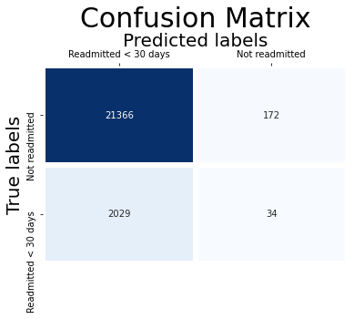

```python
ax = sns.heatmap(cm, annot=True, fmt='g', cmap="Blues", linewidths=5, cbar=False)  #annot=True to annotate cells, ftm='g' to disable scientific notation

# labels, title and ticks
ax.xaxis.set_label_position('top');
ax.xaxis.set_ticks_position('top');

ax.set_xlabel('Predicted labels', size = 20);ax.set_ylabel('True labels', size = 20);
ax.set_title('Confusion Matrix', size = 30);

ax.xaxis.set_ticklabels(['Readmitted < 30 days', 'Not readmitted'])
ax.yaxis.set_ticklabels(['Not readmitted', 'Readmitted < 30 days']);
```

We can easily create a summary of our prediction with the classification report

```python
print(classification_report(y_test, y_pred))
```

```
              precision    recall  f1-score   support

           0       0.91      0.99      0.95     21538
           1       0.17      0.02      0.03      2063

    accuracy                           0.91     23601
   macro avg       0.54      0.50      0.49     23601
weighted avg       0.85      0.91      0.87     23601
```

##### Adding results to the dataframe

```python
knn_sa = pd.DataFrame({'Model': ['K-Nearest Neighbors'],'Score': [sc], 'Accuracy' : [ac]})
models_df = models_df.append(knn_sa, ignore_index=True)

print(pdtabulate(models_df))
```

```
+---------------------+---------+------------+
| Model               |   Score |   Accuracy |
|---------------------+---------+------------|
| K-Nearest Neighbors |  0.9067 |     0.9067 |
+---------------------+---------+------------+
```

#### Model 2: Logistic regression

##### Creating model

```python
from sklearn.linear_model import LogisticRegression

logreg = LogisticRegression()
logreg.fit(x_train,y_train)
```

```
LogisticRegression()
```

##### Computing predictions

```python
y_pred = logreg.predict(x_test)
```

##### Evaluating the performance of the model

```python
cm = confusion_matrix(y_test, y_pred)
ac = accuracy_score(y_test,y_pred)
sc = logreg.score(x_test,y_test)
```

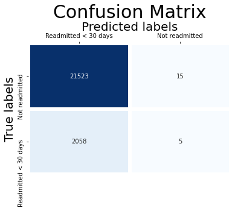

```python
ax = sns.heatmap(cm, annot=True, fmt='g', cmap="Blues", linewidths=5, cbar=False)

ax.xaxis.set_label_position('top');
ax.xaxis.set_ticks_position('top');

ax.set_xlabel('Predicted labels', size = 20);ax.set_ylabel('True labels', size = 20);
ax.set_title('Confusion Matrix', size = 30);

ax.xaxis.set_ticklabels(['Readmitted < 30 days', 'Not readmitted'])
ax.yaxis.set_ticklabels(['Not readmitted', 'Readmitted < 30 days']);
```

```python
print(classification_report(y_test, y_pred))
```

```
              precision    recall  f1-score   support

           0       0.91      1.00      0.95     21538
           1       0.25      0.00      0.00      2063

    accuracy                           0.91     23601
   macro avg       0.58      0.50      0.48     23601
weighted avg       0.85      0.91      0.87     23601
```

##### Adding results to the dataframe

```python
logreg_sa = pd.DataFrame({'Model': ['Logistic Regression'],'Score': [sc], 'Accuracy' : [ac]})
models_df = models_df.append(logreg_sa, ignore_index=True)

print(pdtabulate(models_df))
```

```
+---------------------+---------+------------+
| Model               |   Score |   Accuracy |
|---------------------+---------+------------|
| K-Nearest Neighbors |  0.9067 |     0.9067 |
| Logistic Regression |  0.9122 |     0.9122 |
+---------------------+---------+------------+
```

#### Model 3: Linear SVC

##### Creating model

```python
from sklearn.svm import LinearSVC

lsvc  = LinearSVC( dual = False)
lsvc.fit(x_train, y_train)
```

```
LinearSVC(dual=False)
```

```python
cv_score = cross_val_score(lsvc, x_train, y_train, cv = 10)
print(cv_score.mean())
```

```
0.9117223611397135
```

##### Computing predictions

```python
y_pred = lsvc.predict(x_test)
```

##### Evaluating the performance of the model

```python
ac = accuracy_score(y_test,y_pred)
sc = lsvc.score(x_test,y_test)
cm = confusion_matrix(y_test, y_pred)
```

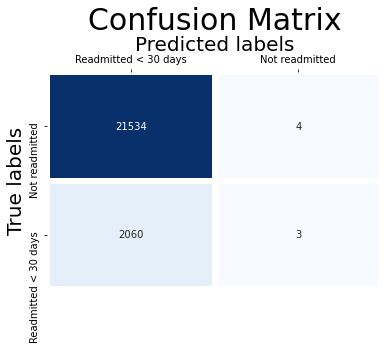

```python
ax = sns.heatmap(cm, annot=True, fmt='g', cmap="Blues", linewidths=5, cbar=False)

ax.xaxis.set_label_position('top');
ax.xaxis.set_ticks_position('top');

ax.set_xlabel('Predicted labels', size = 20);ax.set_ylabel('True labels', size = 20);
ax.set_title('Confusion Matrix', size = 30);

ax.xaxis.set_ticklabels(['Readmitted < 30 days', 'Not readmitted'])
ax.yaxis.set_ticklabels(['Not readmitted', 'Readmitted < 30 days']);
```

```python
print(classification_report(y_test, y_pred))
```

```
              precision    recall  f1-score   support

           0       0.91      1.00      0.95     21538
           1       0.43      0.00      0.00      2063

    accuracy                           0.91     23601
   macro avg       0.67      0.50      0.48     23601
weighted avg       0.87      0.91      0.87     23601
```

##### Adding results to the dataframe

```python
lsvc_sa = pd.DataFrame({'Model': ['Linear SVC'],'Score': [sc], 'Accuracy' : [ac]})
models_df = models_df.append(lsvc_sa, ignore_index=True)

print(pdtabulate(models_df))
```

```
+---------------------+---------+------------+
| Model               |   Score |   Accuracy |
|---------------------+---------+------------|
| K-Nearest Neighbors |  0.9067 |     0.9067 |
| Logistic Regression |  0.9122 |     0.9122 |
| Linear SVC          |  0.9125 |     0.9125 |
+---------------------+---------+------------+
```

#### Model 4: Random Forest

##### Creating model

```python
from sklearn.ensemble import RandomForestClassifier

clf = RandomForestClassifier(n_estimators = 10)
clf = clf.fit(x_train, y_train)
```

```python
from sklearn.model_selection import cross_val_score
scores = cross_val_score( clf, x_train, y_train, cv = 5)
scores.mean()
```

```
0.9110127870601407
```

##### Computing predictions

```python
y_pred = clf.predict(x_test)
```

##### Evaluating the model's performance

```python
cm = confusion_matrix(y_test, y_pred)
ac = accuracy_score(y_test,y_pred)
sc = max(scores) # ???
```

##### Adding results to the dataframe

```python
rf_sa = pd.DataFrame({'Model': ['Random Forest'],'Score': [sc], 'Accuracy' : [ac]})
models_df = models_df.append(rf_sa, ignore_index=True)

print(pdtabulate(models_df))
```

```
+---------------------+---------+------------+
| Model               |   Score |   Accuracy |
|---------------------+---------+------------|
| K-Nearest Neighbors |  0.9067 |     0.9067 |
| Logistic Regression |  0.9122 |     0.9122 |
| Linear SVC          |  0.9125 |     0.9125 |
| Random Forest       |  0.9113 |     0.9117 |
+---------------------+---------+------------+
```

#### Model 5: Adaptive boosting

##### Creating model

```python
from sklearn.ensemble import AdaBoostClassifier

ab = AdaBoostClassifier()
ab.fit(x_train, y_train)
```

```
AdaBoostClassifier()
```

##### Computing predictions

```python
y_pred = ab.predict(x_test)
```

##### Evaluating the model's performance

```python
cm = confusion_matrix(y_test, y_pred)
ac = accuracy_score(y_test,y_pred)
sc = ab.score(x_test,y_test)
```

##### Adding results to the dataframe

```python
rf_sa = pd.DataFrame({'Model': ['Adaptive boosting'],'Score': [sc], 'Accuracy' : [ac]})
models_df = models_df.append(rf_sa, ignore_index=True)

print(pdtabulate(models_df))
```

```
+---------------------+---------+------------+
| Model               |   Score |   Accuracy |
|---------------------+---------+------------|
| K-Nearest Neighbors |  0.9067 |     0.9067 |
| Logistic Regression |  0.9122 |     0.9122 |
| Linear SVC          |  0.9125 |     0.9125 |
| Random Forest       |  0.9113 |     0.9117 |
| Adaptive boosting   |  0.9123 |     0.9123 |
+---------------------+---------+------------+
```

#### Model 6: Decision Tree

##### Creating model

```python
from sklearn.tree import DecisionTreeClassifier

clf = DecisionTreeClassifier(max_depth=None, min_samples_split=2, random_state=0)
scores = cross_val_score(clf, x_train, y_train, cv=5)
scores.mean()
clf.fit( x_train, y_train)
```

```
DecisionTreeClassifier(random_state=0)
```

##### Computing predictions

```python
y_pred = clf.predict(x_test)
```

##### Evaluating the model's performance

```python
cm = confusion_matrix(y_test, y_pred)
ac = accuracy_score(y_test,y_pred)
sc = max(scores) # ???
```

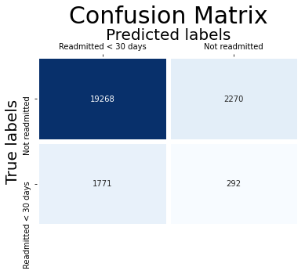

```python
ax = sns.heatmap(cm, annot=True, fmt='g', cmap="Blues", linewidths=5, cbar=False)  #annot=True to annotate cells, ftm='g' to disable scientific notation

# labels, title and ticks
ax.xaxis.set_label_position('top');
ax.xaxis.set_ticks_position('top');

ax.set_xlabel('Predicted labels', size = 20);ax.set_ylabel('True labels', size = 20);
ax.set_title('Confusion Matrix', size = 30);

ax.xaxis.set_ticklabels(['Readmitted < 30 days', 'Not readmitted'])
ax.yaxis.set_ticklabels(['Not readmitted', 'Readmitted < 30 days']);
```

##### Adding results to the dataframe

```python
dt_sa = pd.DataFrame({'Model': ['Decision Tree'],'Score': [sc], 'Accuracy' : [ac]})
models_df = models_df.append(dt_sa, ignore_index=True)

print(pdtabulate(models_df))
```

```
+---------------------+---------+------------+
| Model               |   Score |   Accuracy |
|---------------------+---------+------------|
| K-Nearest Neighbors |  0.9067 |     0.9067 |
| Logistic Regression |  0.9122 |     0.9122 |
| Linear SVC          |  0.9125 |     0.9125 |
| Random Forest       |  0.9113 |     0.9117 |
| Adaptive boosting   |  0.9123 |     0.9123 |
| Decision Tree       |  0.8338 |     0.8288 |
+---------------------+---------+------------+
```

#### Model 7: ExtraTrees

```python
from sklearn.ensemble import ExtraTreesClassifier

clf = ExtraTreesClassifier(n_estimators=10, max_depth=None, min_samples_split=2, random_state=0)
scores = cross_val_score(clf, x_train, y_train, cv=5)
scores.mean()
clf.fit(x_train, y_train)
```

```
ExtraTreesClassifier(n_estimators=10, random_state=0)
```

##### Computing predictions

```python
y_pred = clf.predict(x_test)
```

##### Evaluating the model's performance

```python
cm = confusion_matrix(y_test, y_pred)
ac = accuracy_score(y_test,y_pred)
sc = max(scores) # ???
```

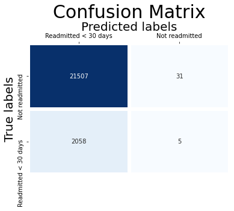

```python
ax = sns.heatmap(cm, annot=True, fmt='g', cmap="Blues", linewidths=5, cbar=False)  #annot=True to annotate cells, ftm='g' to disable scientific notation

# labels, title and ticks
ax.xaxis.set_label_position('top');
ax.xaxis.set_ticks_position('top');

ax.set_xlabel('Predicted labels', size = 20);ax.set_ylabel('True labels', size = 20);
ax.set_title('Confusion Matrix', size = 30);

ax.xaxis.set_ticklabels(['Readmitted < 30 days', 'Not readmitted'])
ax.yaxis.set_ticklabels(['Not readmitted', 'Readmitted < 30 days']);
```

```python
print(classification_report(y_test, y_pred))
```

```
              precision    recall  f1-score   support

           0       0.91      1.00      0.95     21538
           1       0.14      0.00      0.00      2063

    accuracy                           0.91     23601
   macro avg       0.53      0.50      0.48     23601
weighted avg       0.85      0.91      0.87     23601
```

##### Adding results to the dataframe

```python
et_sa = pd.DataFrame({'Model': ['Extra Trees'],'Score': [sc], 'Accuracy' : [ac]})
models_df = models_df.append(et_sa, ignore_index=True)

print(pdtabulate(models_df))
```

```
+---------------------+---------+------------+
| Model               |   Score |   Accuracy |
|---------------------+---------+------------|
| K-Nearest Neighbors |  0.9067 |     0.9067 |
| Logistic Regression |  0.9122 |     0.9122 |
| Linear SVC          |  0.9125 |     0.9125 |
| Random Forest       |  0.9113 |     0.9117 |
| Adaptive boosting   |  0.9123 |     0.9123 |
| Decision Tree       |  0.8338 |     0.8288 |
| Extra Trees         |  0.9110 |     0.9115 |
+---------------------+---------+------------+
```

#### Model 8: Naive Bayes Classifier

##### Creating model

```python
from sklearn.naive_bayes import GaussianNB

gnb = GaussianNB(var_smoothing=1.0)
gnb.fit(x_train, y_train)
```

```
GaussianNB(var_smoothing=1.0)
```

##### Calculating predictions

```python
y_pred = gnb.predict(x_test)
```

##### Evaluating the performance of our model

```python
cm = confusion_matrix(y_test, y_pred)
ac = accuracy_score(y_test,y_pred)
sc = gnb.score(x_test,y_test)
```

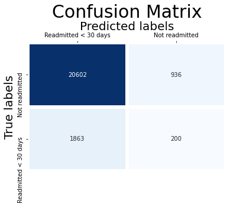

```python
ax = sns.heatmap(cm, annot=True, fmt='g', cmap="Blues", linewidths=5, cbar=False)  #annot=True to annotate cells, ftm='g' to disable scientific notation

# labels, title and ticks
ax.xaxis.set_label_position('top');
ax.xaxis.set_ticks_position('top');

ax.set_xlabel('Predicted labels', size = 20);ax.set_ylabel('True labels', size = 20);
ax.set_title('Confusion Matrix', size = 30);

ax.xaxis.set_ticklabels(['Readmitted < 30 days', 'Not readmitted'])
ax.yaxis.set_ticklabels(['Not readmitted', 'Readmitted < 30 days']);
```

```python
print(classification_report(y_test, y_pred))
```

```
              precision    recall  f1-score   support

           0       0.92      0.96      0.94     21538
           1       0.18      0.10      0.13      2063

    accuracy                           0.88     23601
   macro avg       0.55      0.53      0.53     23601
weighted avg       0.85      0.88      0.87     23601
```

##### Adding results to the dataframe

```python
knn_sa = pd.DataFrame({'Model': ['Naive Bayes'],'Score': [sc], 'Accuracy' : [ac]})
models_df = models_df.append(knn_sa, ignore_index=True)

print(pdtabulate(models_df))
```

```
+---------------------+---------+------------+
| Model               |   Score |   Accuracy |
|---------------------+---------+------------|
| K-Nearest Neighbors |  0.9067 |     0.9067 |
| Logistic Regression |  0.9122 |     0.9122 |
| Linear SVC          |  0.9125 |     0.9125 |
| Random Forest       |  0.9113 |     0.9117 |
| Adaptive boosting   |  0.9123 |     0.9123 |
| Decision Tree       |  0.8338 |     0.8288 |
| Extra Trees         |  0.9110 |     0.9115 |
| Naive Bayes         |  0.8814 |     0.8814 |
+---------------------+---------+------------+
```

### Tuning models

```python
from sklearn.model_selection import GridSearchCV
```

Let's try to find the best hyperparameters using GridSearch

#### Grid Search with Adaptative Boosting

```python
parameters = { 'n_estimators': [100,200,300],
               'learning_rate': [0.95, 0.98, 1.0],
               'algorithm': ['SAMME', 'SAMME.R']}
grid = GridSearchCV(AdaBoostClassifier(), parameters, n_jobs = -1, cv = 3)
grid.fit(x_train,y_train)
y_pred = grid.predict(x_test)
ac = accuracy_score(y_test, y_pred)
sc = grid.best_score_
print(grid.best_estimator_, grid.best_params_)
print(sc, ac)
```

```
AdaBoostClassifier(algorithm='SAMME', learning_rate=0.95, n_estimators=100) {'algorithm': 'SAMME', 'learning_rate': 0.95, 'n_estimators': 100}
0.9117223531589095 0.9125884496419643
```

We can update the dataframe with the new values

```python
models_df.loc[4] = ['Adaptive boosting', sc, ac]
```

#### Grid Search with Random Forest

```python
parameters = {"n_estimators"      : [10,20,50, 100],
              "max_features"      : ["auto", "sqrt", "log2"],
              "min_samples_split" : [2,4,8],
              "bootstrap"         :[True, False],
              }

grid = GridSearchCV(RandomForestClassifier(), parameters, n_jobs = -1, cv = 3)
grid.fit(x_train,y_train)
y_pred = grid.predict(x_test)
ac = accuracy_score(y_test, y_pred)
sc = grid.best_score_
print(grid.best_estimator_, grid.best_params_)
print(sc, ac)
```

```
RandomForestClassifier(max_features='log2', min_samples_split=4,
                       n_estimators=50) {'bootstrap': True, 'max_features': 'log2', 'min_samples_split': 4, 'n_estimators': 50}
0.9117432230144903 0.9125884496419643
```

We can update the dataframe with the new values

```python
models_df.loc[3] = ['Random Forest', sc, ac]
```

#### Grid Search with Naives Bayes

```python
nb_classifier = GaussianNB()

params_NB = {'var_smoothing': np.logspace(0,-9, num=100)}
grid = GridSearchCV(estimator=nb_classifier,
                 param_grid=params_NB,
                 cv=5,   # use any cross validation technique
                 verbose=1,
                 scoring='accuracy')
grid.fit(x_train, y_train)
y_pred = grid.predict(x_test)
ac = accuracy_score(y_test, y_pred)
sc = grid.best_score_
print(grid.best_estimator_, grid.best_params_)
print(sc, ac)
```

```
Fitting 5 folds for each of 100 candidates, totalling 500 fits
GaussianNB(var_smoothing=1.0) {'var_smoothing': 1.0}
0.8853015225731014 0.8814033303673573
```

We can update the dataframe with the new values

```python
models_df.loc[7] = ['Naive Bayes', sc, ac]
```

#### Grid Search with Extra Trees

```python
from sklearn.model_selection import GridSearchCV

parameters = {"n_estimators"      : [10,20,50,100]}

grid = GridSearchCV(ExtraTreesClassifier(), parameters, n_jobs = -1, cv = 3)
grid.fit(x_train,y_train)
y_pred = grid.predict(x_test)
ac = accuracy_score(y_test, y_pred)
sc = grid.best_score_
print(grid.best_estimator_, grid.best_params_)
print(sc, ac)
```

```
ExtraTreesClassifier(n_estimators=50) {'n_estimators': 50}
0.9113675695337519 0.9125460785559933
```

We can update the dataframe with the new values

```python
models_df.loc[6] = ['Extra Trees', sc, ac]
```

### Comparing models

Let's compare all different models we tried.

#### Performance of each model

```python
print(pdtabulate(models_df.sort_values(by=['Score', 'Accuracy'], ascending = False)))
```

```
+---------------------+---------+------------+
| Model               |   Score |   Accuracy |
|---------------------+---------+------------|
| Linear SVC          |  0.9125 |     0.9125 |
| Logistic Regression |  0.9122 |     0.9122 |
| Random Forest       |  0.9117 |     0.9126 |
| Adaptive boosting   |  0.9117 |     0.9126 |
| Extra Trees         |  0.9114 |     0.9125 |
| K-Nearest Neighbors |  0.9067 |     0.9067 |
| Naive Bayes         |  0.8853 |     0.8814 |
| Decision Tree       |  0.8338 |     0.8288 |
+---------------------+---------+------------+
```

#### Plot

```python
bp = models_df[['Model', 'Accuracy']].groupby('Model').sum().plot_bokeh(kind = 'scatter',legend = False, title = 'Accuracy by model', line_cap = 'round',line_dash = 'dotted', show_figure = False)
bp.xaxis.major_label_orientation = np.pi/6
show(bp)
```

[interactive chart not shown]

#### Barplot

```python
from bokeh.models import Range1d
from bokeh.models import Span

bp = models_df.groupby('Model').sum().plot_bokeh(kind = 'barh', title = 'Accuracy and score by model',show_figure = False)
bp.x_range = Range1d(-0.1,1.4)

meanAc = Span(location = models_df.Accuracy.mean(), dimension = 'height', line_color = 'crimson', line_width = 1)
meanSc = Span(location = models_df.Score.mean(), dimension = 'height', line_color = 'blue', line_width = 1)
limit = Span(location = 1, dimension = 'height', line_color = 'black', line_width = 3)

bp.renderers.extend([limit, meanAc, meanSc])
show(bp)
```

[interactive chart not shown]

> As a result, we can conclude that the models predict the data relatively well since the accuracy is around 90%. However, this data is to be nuanced. Looking at the distribution of 0 and 1 data in the readmitted column, we can observe this:

```python
p = diabetes_df_ml['readmitted'].value_counts(normalize = True).sort_values(ascending=False).plot_bokeh(  kind="bar",
                                                                                title = 'Readmitted',
                                                                                fill_alpha = 0.6,
                                                                                legend = False,
                                                                                show_figure=False)
p.xaxis.axis_label = '' # hide x label
p.yaxis.axis_label = '' # hide y label
p.xaxis.major_label_orientation = np.pi/6 # rotate bar labels to improve visibility

show(p)
```

[interactive chart not shown]

> There are only 8.8% of 1 label against 91.2% of 0 label. The problem is also **unbalanced**.

> In this case, we cannot really consider these prediction models reliable.

> We will repeat the same procedure by predicting whether or not a patient can be readmitted, either before or after 30 days.

### Case 2 : Predict patient's readmission under and above 30 days

### Dealing again with the column to predict

We will now consider the question "Will a patient be readmitted below OR above 30 days ?"

> This involve that the 'NO' value will become False and the '<30' value AND the '<30' value will become True

```python
diabetes_df_ml = diabetes_df.drop(columns = ['patient_nbr']).copy()
map_readmitted = {"NO" : False,
                  ">30" : True,
                  "<30" : True}

diabetes_df_ml.readmitted = diabetes_df.readmitted.map(map_readmitted)
```

Let's see the new repartition of the data in this column

```python
p = diabetes_df_ml['readmitted'].value_counts(normalize = True).sort_values(ascending=False).plot_bokeh(  kind="bar",
                                                                                title = 'Readmitted',
                                                                                fill_alpha = 0.6,
                                                                                legend = False,
                                                                                show_figure=False)
p.xaxis.axis_label = '' # hide x label
p.yaxis.axis_label = '' # hide y label
p.xaxis.major_label_orientation = np.pi/6 # rotate bar labels to improve visibility

show(p)
```

[interactive chart not shown]

This is better. Let's do the precedents steps with this new dataset before using Machine Learning models

```python
#change to numerical values for all the columns
from sklearn.preprocessing import LabelEncoder

label_encoder = LabelEncoder()

diabetes_df_ml["race"] = label_encoder.fit_transform(diabetes_df_ml["race"].astype(str))
#diabetes_df_ml["readmitted"] = label_encoder.fit_transform(diabetes_df_ml["readmitted"].astype(str))

for column in diabetes_df_ml.select_dtypes(include=['object']).columns:
    diabetes_df_ml[column] = label_encoder.fit_transform(diabetes_df_ml[column])

for column in diabetes_df_ml.select_dtypes(include=['bool']).columns:
    diabetes_df_ml[column] = label_encoder.fit_transform(diabetes_df_ml[column])

#shuffle the rows
diabetes_df_ml = diabetes_df_ml.sample(n = len(diabetes_df_ml), random_state = 42)

#splitting the dataset
from sklearn.model_selection import train_test_split

x = diabetes_df_ml.loc[:, diabetes_df_ml.columns != 'readmitted'] # every feature except the one that we will try to predict
y = diabetes_df_ml.loc[:, 'readmitted'] # readmitted feature
x_train, x_test, y_train, y_test = train_test_split(x,y, test_size = 0.33)

#scaling the dataset
from sklearn.preprocessing import StandardScaler

scaler = StandardScaler()
scaler.fit(x_train)
x_train = scaler.transform(x_train)
x_test = scaler.transform(x_test)

#results modelisation
models_df2 = pd.DataFrame(columns=['Model', 'Score', 'Accuracy'])
pdtabulate2 = lambda df: tabulate(df, headers='keys', tablefmt='psql', floatfmt=".4f", showindex=False)
print(pdtabulate2(models_df2))
```

```
+---------+---------+------------+
| Model   | Score   | Accuracy   |
|---------+---------+------------|
+---------+---------+------------+
```

#### Model 1: K-Nearest Neighbors (KNN)

```
              precision    recall  f1-score   support

           0       0.63      0.71      0.67     14240
           1       0.46      0.37      0.41      9361

    accuracy                           0.58     23601
   macro avg       0.54      0.54      0.54     23601
weighted avg       0.56      0.58      0.57     23601

+---------------------+---------+------------+
| Model               |   Score |   Accuracy |
|---------------------+---------+------------|
| K-Nearest Neighbors |  0.5756 |     0.5756 |
+---------------------+---------+------------+
```

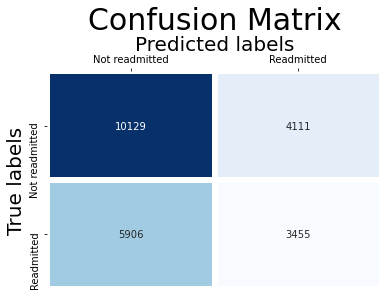

```python
knn = KNeighborsClassifier(n_neighbors = 5)
knn.fit(x_train, y_train)

## Computing predictions
y_pred = knn.predict(x_test)

## Evaluating the performance of the model
cm = confusion_matrix(y_test, y_pred)
ac = accuracy_score(y_test,y_pred)
sc = knn.score(x_test,y_test)

ax = sns.heatmap(cm, annot=True, fmt='g', cmap="Blues", linewidths=5, cbar=False)  #annot=True to annotate cells, ftm='g' to disable scientific notation

# labels, title and ticks
ax.xaxis.set_label_position('top');
ax.xaxis.set_ticks_position('top');

ax.set_xlabel('Predicted labels', size = 20);ax.set_ylabel('True labels', size = 20);
ax.set_title('Confusion Matrix', size = 30);

ax.xaxis.set_ticklabels(['Not readmitted', 'Readmitted'])
ax.yaxis.set_ticklabels(['Not readmitted', 'Readmitted']);

print(classification_report(y_test, y_pred))

## Adding results to the dataframe
knn_sa = pd.DataFrame({'Model': ['K-Nearest Neighbors'],'Score': [sc], 'Accuracy' : [ac]})
models_df2 = models_df2.append(knn_sa, ignore_index=True)

print(pdtabulate2(models_df2))
```

#### Model 2: Logistic regression

```
              precision    recall  f1-score   support

           0       0.63      0.90      0.74     14240
           1       0.57      0.21      0.30      9361

    accuracy                           0.62     23601
   macro avg       0.60      0.55      0.52     23601
weighted avg       0.61      0.62      0.57     23601

+---------------------+---------+------------+
| Model               |   Score |   Accuracy |
|---------------------+---------+------------|
| K-Nearest Neighbors |  0.5756 |     0.5756 |
| Logistic Regression |  0.6241 |     0.6241 |
+---------------------+---------+------------+
```

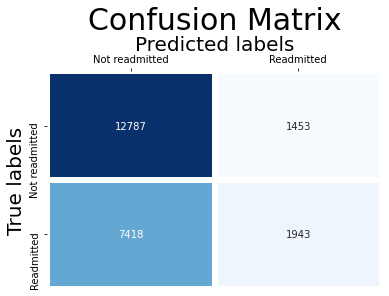

```python
## Creating model
logreg = LogisticRegression()
logreg.fit(x_train,y_train)

## Computing predictions
y_pred = logreg.predict(x_test)

## Evaluating the performance of the model
cm = confusion_matrix(y_test, y_pred)
ac = accuracy_score(y_test,y_pred)
sc = logreg.score(x_test,y_test)

ax = sns.heatmap(cm, annot=True, fmt='g', cmap="Blues", linewidths=5, cbar=False)

ax.xaxis.set_label_position('top');
ax.xaxis.set_ticks_position('top');

ax.set_xlabel('Predicted labels', size = 20);ax.set_ylabel('True labels', size = 20);
ax.set_title('Confusion Matrix', size = 30);

ax.xaxis.set_ticklabels(['Not readmitted', 'Readmitted'])
ax.yaxis.set_ticklabels(['Not readmitted', 'Readmitted']);

print(classification_report(y_test, y_pred))

## Adding results to the dataframe

logreg_sa = pd.DataFrame({'Model': ['Logistic Regression'],'Score': [sc], 'Accuracy' : [ac]})
models_df2 = models_df2.append(logreg_sa, ignore_index=True)

print(pdtabulate2(models_df2))
```

#### Model 3: Linear SVC

```
0.6260201245100284
              precision    recall  f1-score   support

           0       0.63      0.91      0.74     14240
           1       0.58      0.19      0.29      9361

    accuracy                           0.62     23601
   macro avg       0.61      0.55      0.52     23601
weighted avg       0.61      0.62      0.56     23601

+---------------------+---------+------------+
| Model               |   Score |   Accuracy |
|---------------------+---------+------------|
| K-Nearest Neighbors |  0.5756 |     0.5756 |
| Logistic Regression |  0.6241 |     0.6241 |
| Linear SVC          |  0.6246 |     0.6246 |
+---------------------+---------+------------+
```

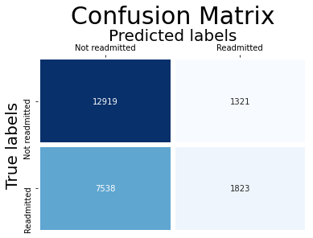

```python
## Creating model
lsvc  = LinearSVC( dual = False)
lsvc.fit(x_train, y_train)

cv_score = cross_val_score(lsvc, x_train, y_train, cv = 10)
print(cv_score.mean())

## Computing predictions
y_pred = lsvc.predict(x_test)

## Evaluating the performance of the model
ac = accuracy_score(y_test,y_pred)
sc = lsvc.score(x_test,y_test)
cm = confusion_matrix(y_test, y_pred)

ax = sns.heatmap(cm, annot=True, fmt='g', cmap="Blues", linewidths=5, cbar=False)

ax.xaxis.set_label_position('top');
ax.xaxis.set_ticks_position('top');

ax.set_xlabel('Predicted labels', size = 20);ax.set_ylabel('True labels', size = 20);
ax.set_title('Confusion Matrix', size = 30);

ax.xaxis.set_ticklabels(['Not readmitted', 'Readmitted'])
ax.yaxis.set_ticklabels(['Not readmitted', 'Readmitted']);

print(classification_report(y_test, y_pred))

## Adding results to the dataframe
lsvc_sa = pd.DataFrame({'Model': ['Linear SVC'],'Score': [sc], 'Accuracy' : [ac]})
models_df2 = models_df2.append(lsvc_sa, ignore_index=True)

print(pdtabulate2(models_df2))
```

#### Model 4: Random Forest

```python
## Creating model
clf = RandomForestClassifier(n_estimators = 10)
clf = clf.fit(x_train, y_train)

scores = cross_val_score( clf, x_train, y_train, cv = 5)
scores.mean()

## Computing predictions
y_pred = clf.predict(x_test)

## Evaluating the model's performance
cm = confusion_matrix(y_test, y_pred)
ac = accuracy_score(y_test,y_pred)
sc = max(scores) # ???

## Adding results to the dataframe
rf_sa = pd.DataFrame({'Model': ['Random Forest'],'Score': [sc], 'Accuracy' : [ac]})
models_df2 = models_df2.append(rf_sa, ignore_index=True)

print(pdtabulate2(models_df2))
```

```
+---------------------+---------+------------+
| Model               |   Score |   Accuracy |
|---------------------+---------+------------|
| K-Nearest Neighbors |  0.5756 |     0.5756 |
| Logistic Regression |  0.6241 |     0.6241 |
| Linear SVC          |  0.6246 |     0.6246 |
| Random Forest       |  0.6110 |     0.6073 |
+---------------------+---------+------------+
```

#### Model 5: Adaptive boosting

```python
## Creating model
ab = AdaBoostClassifier()
ab.fit(x_train, y_train)

## Computing predictions
y_pred = ab.predict(x_test)

## Evaluating the model's performance
cm = confusion_matrix(y_test, y_pred)
ac = accuracy_score(y_test,y_pred)
sc = ab.score(x_test,y_test)

## Adding results to the dataframe
rf_sa = pd.DataFrame({'Model': ['Adaptive boosting'],'Score': [sc], 'Accuracy' : [ac]})
models_df2 = models_df2.append(rf_sa, ignore_index=True)

print(pdtabulate2(models_df2))
```

```
+---------------------+---------+------------+
| Model               |   Score |   Accuracy |
|---------------------+---------+------------|
| K-Nearest Neighbors |  0.5756 |     0.5756 |
| Logistic Regression |  0.6241 |     0.6241 |
| Linear SVC          |  0.6246 |     0.6246 |
| Random Forest       |  0.6110 |     0.6073 |
| Adaptive boosting   |  0.6335 |     0.6335 |
+---------------------+---------+------------+
```

#### Model 6: Decision Tree

```
+---------------------+---------+------------+
| Model               |   Score |   Accuracy |
|---------------------+---------+------------|
| K-Nearest Neighbors |  0.5756 |     0.5756 |
| Logistic Regression |  0.6241 |     0.6241 |
| Linear SVC          |  0.6246 |     0.6246 |
| Random Forest       |  0.6110 |     0.6073 |
| Adaptive boosting   |  0.6335 |     0.6335 |
| Decision Tree       |  0.5702 |     0.5604 |
+---------------------+---------+------------+
```

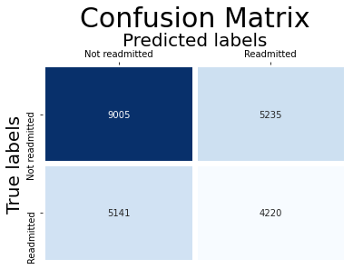

```python
## Creating model
clf = DecisionTreeClassifier(max_depth=None, min_samples_split=2, random_state=0)
scores = cross_val_score(clf, x_train, y_train, cv=5)
scores.mean()
clf.fit( x_train, y_train)

## Computing predictions
y_pred = clf.predict(x_test)

## Evaluating the model's performance
cm = confusion_matrix(y_test, y_pred)
ac = accuracy_score(y_test,y_pred)
sc = max(scores) # ???

ax = sns.heatmap(cm, annot=True, fmt='g', cmap="Blues", linewidths=5, cbar=False)  #annot=True to annotate cells, ftm='g' to disable scientific notation

# labels, title and ticks
ax.xaxis.set_label_position('top');
ax.xaxis.set_ticks_position('top');

ax.set_xlabel('Predicted labels', size = 20);ax.set_ylabel('True labels', size = 20);
ax.set_title('Confusion Matrix', size = 30);

ax.xaxis.set_ticklabels(['Not readmitted', 'Readmitted'])
ax.yaxis.set_ticklabels(['Not readmitted', 'Readmitted']);

## Adding results to the dataframe
dt_sa = pd.DataFrame({'Model': ['Decision Tree'],'Score': [sc], 'Accuracy' : [ac]})
models_df2 = models_df2.append(dt_sa, ignore_index=True)

print(pdtabulate2(models_df2))
```

#### Model 7: ExtraTrees

```
              precision    recall  f1-score   support

           0       0.63      0.81      0.71     14240
           1       0.50      0.29      0.36      9361

    accuracy                           0.60     23601
   macro avg       0.57      0.55      0.54     23601
weighted avg       0.58      0.60      0.57     23601

+---------------------+---------+------------+
| Model               |   Score |   Accuracy |
|---------------------+---------+------------|
| K-Nearest Neighbors |  0.5756 |     0.5756 |
| Logistic Regression |  0.6241 |     0.6241 |
| Linear SVC          |  0.6246 |     0.6246 |
| Random Forest       |  0.6110 |     0.6073 |
| Adaptive boosting   |  0.6335 |     0.6335 |
| Decision Tree       |  0.5702 |     0.5604 |
| Extra Trees         |  0.6016 |     0.6031 |
+---------------------+---------+------------+
```

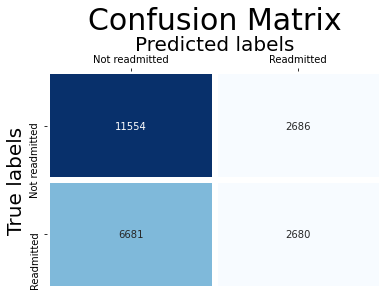

```python
##Creating model
clf = ExtraTreesClassifier(n_estimators=10, max_depth=None, min_samples_split=2, random_state=0)
scores = cross_val_score(clf, x_train, y_train, cv=5)
scores.mean()
clf.fit(x_train, y_train)

## Computing predictions
y_pred = clf.predict(x_test)

## Evaluating the model's performance
cm = confusion_matrix(y_test, y_pred)
ac = accuracy_score(y_test,y_pred)
sc = max(scores) # ???

ax = sns.heatmap(cm, annot=True, fmt='g', cmap="Blues", linewidths=5, cbar=False)  #annot=True to annotate cells, ftm='g' to disable scientific notation

# labels, title and ticks
ax.xaxis.set_label_position('top');
ax.xaxis.set_ticks_position('top');

ax.set_xlabel('Predicted labels', size = 20);ax.set_ylabel('True labels', size = 20);
ax.set_title('Confusion Matrix', size = 30);

ax.xaxis.set_ticklabels(['Not readmitted', 'Readmitted'])
ax.yaxis.set_ticklabels(['Not readmitted', 'Readmitted']);

print(classification_report(y_test, y_pred))

## Adding results to the dataframe
et_sa = pd.DataFrame({'Model': ['Extra Trees'],'Score': [sc], 'Accuracy' : [ac]})
models_df2 = models_df2.append(et_sa, ignore_index=True)

print(pdtabulate(models_df2))
```

#### Model 8: Naive Bayes Classifier

```
              precision    recall  f1-score   support

           0       0.61      0.99      0.75     14240
           1       0.65      0.02      0.04      9361

    accuracy                           0.61     23601
   macro avg       0.63      0.51      0.40     23601
weighted avg       0.62      0.61      0.47     23601

+---------------------+---------+------------+
| Model               |   Score |   Accuracy |
|---------------------+---------+------------|
| K-Nearest Neighbors |  0.5756 |     0.5756 |
| Logistic Regression |  0.6241 |     0.6241 |
| Linear SVC          |  0.6246 |     0.6246 |
| Random Forest       |  0.6110 |     0.6073 |
| Adaptive boosting   |  0.6335 |     0.6335 |
| Decision Tree       |  0.5702 |     0.5604 |
| Extra Trees         |  0.6016 |     0.6031 |
| Naive Bayes         |  0.6074 |     0.6074 |
+---------------------+---------+------------+
```

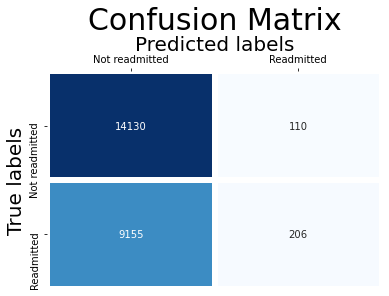

```python
## Creating model
gnb = GaussianNB()
gnb.fit(x_train, y_train)

## Calculating predictions
y_pred = gnb.predict(x_test)

## Evaluating the performance of our model
cm = confusion_matrix(y_test, y_pred)
ac = accuracy_score(y_test,y_pred)
sc = gnb.score(x_test,y_test)

ax = sns.heatmap(cm, annot=True, fmt='g', cmap="Blues", linewidths=5, cbar=False)  #annot=True to annotate cells, ftm='g' to disable scientific notation

# labels, title and ticks
ax.xaxis.set_label_position('top');
ax.xaxis.set_ticks_position('top');

ax.set_xlabel('Predicted labels', size = 20);ax.set_ylabel('True labels', size = 20);
ax.set_title('Confusion Matrix', size = 30);

ax.xaxis.set_ticklabels(['Not readmitted', 'Readmitted'])
ax.yaxis.set_ticklabels(['Not readmitted', 'Readmitted']);

print(classification_report(y_test, y_pred))

## Adding results to the dataframe
knn_sa = pd.DataFrame({'Model': ['Naive Bayes'],'Score': [sc], 'Accuracy' : [ac]})
models_df2 = models_df2.append(knn_sa, ignore_index=True)

print(pdtabulate(models_df2))
```

The best score is obtained with the adaptive boosting model. Let's try other hyperparameters. Maybe we can improve the performance of the model.

### Tuning models

Again, let's try to find the best hyperparameters using GridSearch

#### Grid Search with Adaptative Boosting

```python
parameters = { 'n_estimators': [100,200,300],
               'learning_rate': [0.95, 0.98, 1.0],
               'algorithm': ['SAMME', 'SAMME.R']}
grid = GridSearchCV(AdaBoostClassifier(), parameters, n_jobs = -1, cv = 3)
grid.fit(x_train,y_train)
y_pred = grid.predict(x_test)
ac = accuracy_score(y_test, y_pred)
sc = grid.best_score_
print(grid.best_estimator_, grid.best_params_)
print(sc, ac)
```

```
AdaBoostClassifier(learning_rate=0.98, n_estimators=300) {'algorithm': 'SAMME.R', 'learning_rate': 0.98, 'n_estimators': 300}
0.638165992003149 0.6351425787042921
```

The best parameters to use with the AdaBoostClassifier are n_estimators = 300, learning_rate = 0.98. The score of the model is a little bit improved but it's not enormous.

We can update the dataframe with the new values

```python
models_df2.loc[4] = ['Adaptive boosting', sc, ac]
```

#### Grid Search with Random Forest

```python
from sklearn.model_selection import GridSearchCV

parameters = {"n_estimators"      : [10,20,50, 100],
              "max_features"      : ["auto", "sqrt", "log2"],
              "min_samples_split" : [2,4,8],
              "bootstrap"         :[True, False],
              }

grid = GridSearchCV(RandomForestClassifier(), parameters, n_jobs = -1, cv = 3)
grid.fit(x_train,y_train)
y_pred = grid.predict(x_test)
ac = accuracy_score(y_test, y_pred)
sc = grid.best_score_
print(grid.best_estimator_, grid.best_params_)
print(sc, ac)
```

```
RandomForestClassifier(max_features='sqrt', min_samples_split=8) {'bootstrap': True, 'max_features': 'sqrt', 'min_samples_split': 8, 'n_estimators': 100}
0.6360790796130545 0.6347612389305538
```

We can update the dataframe with the new values

```python
models_df2.loc[3] = ['Random Forest', sc, ac]
```

#### Grid Search with Naives Bayes

```python
nb_classifier = GaussianNB()

params_NB = {'var_smoothing': np.logspace(0,-9, num=100)}
gs_NB = GridSearchCV(estimator=nb_classifier,
                 param_grid=params_NB,
                 cv=5,   # use any cross validation technique
                 verbose=1,
                 scoring='accuracy')
gs_NB.fit(x_train, y_train)
y_pred = grid.predict(x_test)
ac = accuracy_score(y_test, y_pred)
sc = grid.best_score_
print(grid.best_estimator_, grid.best_params_)
print(sc, ac)
```

```
Fitting 5 folds for each of 100 candidates, totalling 500 fits
RandomForestClassifier(max_features='sqrt', min_samples_split=8) {'bootstrap': True, 'max_features': 'sqrt', 'min_samples_split': 8, 'n_estimators': 100}
0.6360790796130545 0.6347612389305538
```

We can update the dataframe with the new values

```python
models_df2.loc[7] = ['Naive Bayes', sc, ac]
```

#### Grid Search with Extra Trees

```python
from sklearn.model_selection import GridSearchCV

parameters = {"n_estimators"      : [10,20,50,100]}

grid = GridSearchCV(ExtraTreesClassifier(), parameters, n_jobs = -1, cv = 3)
grid.fit(x_train,y_train)
y_pred = grid.predict(x_test)
ac = accuracy_score(y_test, y_pred)
sc = grid.best_score_
print(grid.best_estimator_, grid.best_params_)
print(sc, ac)
```

```
ExtraTreesClassifier() {'n_estimators': 100}
0.6220130830907383 0.6241684674378204
```

We can update the dataframe with the new values

```python
models_df2.loc[6] = ['Extra Trees', sc, ac]
```

#### Performance of each model

#### Plot

```python
bp = models_df2[['Model', 'Accuracy']].groupby('Model').sum().plot_bokeh(kind = 'scatter',legend = False, title = 'Accuracy by model', line_cap = 'round',line_dash = 'dotted', show_figure = False)
bp.xaxis.major_label_orientation = np.pi/6
show(bp)
```

[interactive chart not shown]

#### Barplot

```python
from bokeh.models import Range1d
from bokeh.models import Span

bp = models_df2.groupby('Model').sum().plot_bokeh(kind = 'barh', title = 'Accuracy and score by model',show_figure = False)
bp.x_range = Range1d(-0.1,1.4)

meanAc = Span(location = models_df.Accuracy.mean(), dimension = 'height', line_color = 'crimson', line_width = 1)
meanSc = Span(location = models_df.Score.mean(), dimension = 'height', line_color = 'blue', line_width = 1)
limit = Span(location = 1, dimension = 'height', line_color = 'white', line_width = 3)

bp.renderers.extend([limit, meanAc, meanSc])
show(bp)
```

[interactive chart not shown]

## Conclusion

### Remarks about cases

Let's summarize what we have done yet.  
We made two different hypothesis concerning our machine learning predictions:

- 1. Predict if patients will be readmitted under 30 days
- 1. Predict if patients will be readmitted (ie under or over 30 days)

Each hypothesis led to different results due to the different proportions of values.  
Now that we run some models on both, we can compare them.

Let's concatenate both dataframe to have a holistic view of our results.

```python
summary_ML = pd.concat([models_df, models_df2],
                               axis = 1,
                               keys=['Readmission under 30 days', 'Readmission under or over 30 days'])
```

Now that we have a dataframe containing all reults from our models, we can save it to a csv file.

```python
summary_ML.to_csv(r'..\Dataset\summary_ML.csv', index=False, sep = ';')
```

```python
#headerstyle = {'selector': 'tr', 'props': [('background-color', 'lightblue') ,('border','1.5px solid black')]}
#rowstyle = {'selector': 'td', 'props': [('background-color', 'white') ,('border','1.5px solid black')]}
```

```python
summary_ML.style.hide_index().highlight_max(color = 'lightgreen').highlight_min(color = 'red')
```

| Readmission under 30 days Model | Readmission under 30 days Score | Readmission under 30 days Accuracy | Readmission under or over 30 days Model | Readmission under or over 30 days Score | Readmission under or over 30 days Accuracy |
| --- | --- | --- | --- | --- | --- |
| K-Nearest Neighbors | 0.906741 | 0.906741 | K-Nearest Neighbors | 0.575569 | 0.575569 |
| Logistic Regression | 0.912165 | 0.912165 | Logistic Regression | 0.624126 | 0.624126 |
| Linear SVC | 0.912546 | 0.912546 | Linear SVC | 0.624635 | 0.624635 |
| Random Forest | 0.911743 | 0.912588 | Random Forest | 0.636079 | 0.634761 |
| Adaptive boosting | 0.911722 | 0.912588 | Adaptive boosting | 0.638166 | 0.635143 |
| Decision Tree | 0.833785 | 0.828778 | Decision Tree | 0.570221 | 0.560358 |
| Extra Trees | 0.911368 | 0.912546 | Extra Trees | 0.622013 | 0.624168 |
| Naive Bayes | 0.885302 | 0.881403 | Naive Bayes | 0.636079 | 0.634761 |

```python
summary_ML['Readmission under 30 days'].Accuracy.mean(), summary_ML['Readmission under or over 30 days'].Accuracy.mean()
```

```
(0.8974196008643701, 0.6141900766916655)
```

We can see that the differents models perform better in case 1 but as mentionned earlier it is not surprising because the two categories to predict are too unbalanced.

In case 2, we lost some accuracy but it is a much more realistic modelization